```python
import nbconvert
!jupyter nbconvert --to html "risk index.ipynb"
```

# 📊 Framework Multidimensional de Incertidumbre Económica

## Risk Index

### 🎯 **Descripción General**

Este notebook implementa un **framework multidimensional para la cuantificación de incertidumbre económica** basado en la investigación académica desarrollada en los papers:

- *"A Multidimensional Framework for Economic Uncertainty Quantification"*
- *"Fiscal Policy Errors Under Economic Uncertainty: A DSGE Model with Imperfect Information and Learning"*

El framework va más allá de los índices tradicionales de incertidumbre al capturar **múltiples dimensiones** de ambigüedad predictiva, proporcionando una visión más completa y matizada del riesgo económico.

### 🔬 **Marco Teórico**

La incertidumbre económica se descompone en **tres dimensiones fundamentales**:

#### 1. **Model Dispersion (Dispersión entre Modelos)**

- 📈 Captura el **desacuerdo** entre diferentes metodologías de forecasting
- 🎯 Mide la **incertidumbre estructural** sobre el modelo económico apropiado
- 🔄 Identifica períodos donde distintos marcos analíticos proporcionan recomendaciones conflictivas

#### 2. **Within-Model Variability (Variabilidad Intra-Modelo)**

- 📊 Mide el **rango de resultados plausibles** dentro de un marco de modelado específico
- 🎲 Corresponde a la **incertidumbre paramétrica** y volatilidad estocástica
- ⚡ Captura la **volatilidad impredecible** de las series económicas

#### 3. **Temporal Instability (Inestabilidad Temporal)**

- ⏰ Refleja **cambios en las predicciones** conforme nueva información está disponible
- 🔄 Indica incertidumbre sobre la **persistencia** de relaciones económicas
- 📊 Mide la **revisión sustancial** de forecasts a lo largo del tiempo

### 🛠️ **Arquitectura del Sistema**

El notebook está estructurado en **módulos funcionalmente cohesivos**:

```
📁 Risk Index Framework
├── 🔄 Data Processing & Transformation
├── 🤖 Multi-Model Forecasting Engine
├── 📊 Uncertainty Quantification
├── 🧠 Model Resilience Analysis
├── 📈 Composite Index Construction
└── 📋 Visualization & Reporting
```

### 🤖 **Modelos Implementados**

#### **1. Vector Autoregression (VAR)**

- **Propósito**: Modelo econométrico tradicional para análisis multivariado
- **Fortalezas**: Captura relaciones dinámicas entre variables económicas
- **Uso**: Generación de intervalos de confianza (within-model uncertainty)

#### **2. Random Forest**

- **Propósito**: Modelo de machine learning para capturar no-linealidades
- **Fortalezas**: Robusto ante outliers y cambios estructurales
- **Uso**: Modelo alternativo para dispersión entre modelos

#### **3. ARIMA (AutoRegressive Integrated Moving Average)**

- **Propósito**: Modelo univariado clásico de series temporales
- **Fortalezas**: Simplicidad y transparencia interpretativa
- **Uso**: Tercer modelo para completar la dispersión multidimensional

### 📊 **Metodología de Evaluación**

#### **Rolling Window Analysis**

- 🔄 **Evaluación dinámica** desde 2019Q1 hasta 2025Q1
- 📈 **Forecasting out-of-sample** con ventana móvil
- 🎯 **Métricas de performance**: MAE, RMSE, intervalos de confianza

#### **Crisis Resilience Framework**

- 🦠 **Análisis pre/post-COVID** para medir adaptabilidad de modelos
- 🔧 **Resilience Score** = 1 / (Post-COVID MAE / Pre-COVID MAE)
- 📊 **Clasificación**: Modelos resilientes vs. modelos con "trauma estructural"

### 🎨 **Outputs del Sistema**

#### **1. Índice Compuesto de Incertidumbre**

```
Composite_Index = w₁ × Model_Dispersion +
                  w₂ × Within_Model_Variability +
                  w₃ × Temporal_Instability
```

#### **2. Clasificación por Regímenes**

- 🟢 **Normal** (0-50): Condiciones económicas típicas
- 🟡 **Elevada** (50-75): Ambigüedad económica acentuada
- 🟠 **Alta** (75-90): Incertidumbre significativa
- 🔴 **Extrema** (90-100): Condiciones de cambio de régimen/crisis

#### **3. Dashboard de Visualización**

- 📈 **Series temporales** de forecasts vs. realización
- 📊 **Análisis de errores** y distribuciones
- 🎯 **Decomposición de incertidumbre** por dimensiones
- 🔥 **Heatmaps de correlación** y dispersión

### 🔑 **Innovaciones Metodológicas**

#### **Model Resilience Analysis**

- 🧠 **Concepto**: Capacidad de los modelos para recuperarse tras shocks extremos
- 📊 **Hallazgo clave**: Los modelos VAR sufren "trauma estructural" post-COVID
- 🎯 **Implicación**: Necesidad de mayor peso en modelos resilientes durante crisis

#### **Enhanced Composite Index**

- 🔗 **Integración multidimensional** con pesos optimizados empíricamente
- 📈 **Poder predictivo** para identificación de períodos de estrés económico
- ⚡ **Actualización en tiempo real** conforme nueva data está disponible

### 📈 **Resultados Principales**

#### **Performance de Modelos (MAE)**

| Modelo | MAE | Ranking |
| --- | --- | --- |
| **Random Forest** | 2.34 | 🥇 1° |
| **ARIMA** | 4.26 | 🥈 2° |
| **VAR** | 6.22 | 🥉 3° |

#### **Resilience Scores**

| Modelo | Resilience Score | Clasificación |
| --- | --- | --- |
| **Random Forest** | 1.096 | 🟢 Alta Resiliencia |
| **ARIMA** | 0.303 | 🟡 Resiliencia Media |
| **VAR** | 0.064 | 🔴 Baja Resiliencia |

### 🚀 **Aplicaciones Prácticas**

#### **Para Policymakers**

- 🎯 **Timing de intervenciones** fiscales basado en régimens de incertidumbre
- 📊 **Evaluation de efectividad** de políticas bajo diferentes niveles de ambigüedad
- ⚡ **Early warning system** para crisis económicas emergentes

#### **Para Instituciones Financieras**

- 💼 **Risk management** y asignación de capital
- 📈 **Stress testing** bajo escenarios de incertidumbre extrema
- 🔍 **Due diligence** mejorado para decisiones de inversión

#### **Para Investigadores**

- 📚 **Framework replicable** para análisis de incertidumbre
- 🔬 **Metodología extensible** a diferentes economías y sectores
- 📊 **Benchmarking** de nuevos modelos de forecasting

### 📋 **Estructura del Notebook**

1. **Data Loading & Preprocessing** 📥
2. **Model Training & Validation** 🤖
3. **Rolling Forecast Evaluation** 🔄
4. **Uncertainty Quantification** 📊
5. **Model Resilience Analysis** 🧠
6. **Composite Index Construction** 🏗️
7. **Visualization & Reporting** 📈

### 🔧 **Requisitos Técnicos**

```
# Principales librerías utilizadas
import pandas as pd              # Manipulación de datos
import numpy as np               # Cálculos numéricos
import matplotlib.pyplot as plt  # Visualizaciones
import statsmodels.api as sm     # Modelos econométricos
from sklearn.ensemble import RandomForestRegressor  # ML
import warnings
warnings.filterwarnings("ignore")
```

### 📞 **Contacto y Referencias**

**Autores**: Manuel Hidalgo-Pérez, Leandro Airef  
**Institución**: Universidad Pablo de Olavide, AIREF  
**Proyecto**: Crisis Tracker v2 - Risk Index Framework

> 💡 **Nota**: Este framework representa una **contribución metodológica significativa** al campo de la quantificación de incertidumbre económica, proporcionando herramientas tanto teóricas como prácticas para la comprensión y gestión del riesgo macroeconómico.

## 📥 **Módulo de Carga y Procesamiento de Datos**

Este módulo constituye la **base fundamental** del framework de incertidumbre económica, encargándose de la importación, transformación y preparación de las series temporales económicas que alimentan los modelos de forecasting.

### 🎯 **Objetivos del Módulo**

- **Carga automatizada** de datos económicos desde archivos Excel vintage
- **Transformaciones estadísticas** (logaritmos, desestacionalización, diferenciación)
- **Normalización** de series temporales para análisis econométrico
- **Gestión de vintages** para análisis histórico y evaluación out-of-sample

### 🔄 **Pipeline de Transformaciones**

El sistema aplica una **secuencia robusta** de transformaciones a cada serie temporal:

#### **1. Transformación Logarítmica**

```
if log[i] == 1:
    dta[name] = np.log(dta[name])
```

- **Propósito**: Estabilizar varianza y linearizar tendencias exponenciales
- **Aplicación**: Series con crecimiento compuesto (PIB, precios, salarios)

#### **2. Desestacionalización (X-13 ARIMA-SEATS)**

```
if detrend[i] == 1:
    resultst = x13_arima_analysis(endog=ser, prefer_x13=True, outlier=True)
    dta[name] = resultst.seasadj
```

- **Método**: X-13 ARIMA-SEATS (estándar del U.S. Census Bureau)
- **Beneficio**: Elimina patrones estacionales para análisis de ciclo económico
- **Configuración**: Detección automática de outliers habilitada

#### **3. Diferenciación**

```
if difer[i] != 0:
    dta[name] = dta[name].diff(difer[i]) * 100
```

- **Propósito**: Convertir niveles a tasas de crecimiento
- **Escalado**: Multiplicación por 100 para expresar en porcentajes
- **Flexibilidad**: Diferenciación de orden variable según características de la serie

#### **4. Desplazamiento Temporal**

```
if cross[i] != 0:
    dta[name] = dta[name].shift(cross[i])
```

- **Aplicación**: Ajuste de timing para indicadores adelantados/retrasados
- **Uso**: Sincronización de series con diferentes lags informativos

### 📊 **Gestión de Datos Vintage**

El sistema implementa una **arquitectura vintage** que preserva el contexto histórico:

- **Vintage Dating**: Cada dataset refleja la información disponible en una fecha específica
- **Real-time Analysis**: Permite evaluación de modelos en condiciones realistas
- **Historical Consistency**: Mantiene trazabilidad de revisiones de datos

### 🗂️ **Estructura de Datos**

#### **Datos Mensuales**

- **Frecuencia**: Mensual (M)
- **Scope**: Indicadores de alta frecuencia (producción industrial, empleo, PMI)
- **Transformación**: Aplicación completa del pipeline según configuración

#### **Datos Trimestrales**

- **Frecuencia**: Trimestral (Q)
- **Scope**: Cuentas nacionales y agregados macroeconómicos
- **Intervención COVID**: Incorporación de variables dummy para período pandémico

### ⚙️ **Configuración Paramétrica**

El sistema utiliza **archivos de configuración** que especifican las transformaciones:

```
series_m = pd.read_excel(fichero_mensual)    # Configuración mensual
series_q = pd.read_excel(fichero_trimestral) # Configuración trimestral
```

**Parámetros por serie**:

- `logs`: Aplicar transformación logarítmica (0/1)
- `detrend`: Aplicar desestacionalización (0/1)
- `difer`: Orden de diferenciación (0, 1, 2...)
- `cross`: Desplazamiento temporal (+/- períodos)

### 📁 **Organización de Archivos**

```
data/
├── Vintage/
│   ├── monthly/IIT2025/
│   │   └── 2025_05_23_m_rev.xlsx
│   ├── quarterly/IIT2025/
│   │   └── 2025_05_23_q_rev.xlsx
│   └── desest/
│       ├── 2025_05_23_m_dtrend.xlsx
│       └── 2025_05_23_q_dtrend.xlsx
└── Ficheros bdsice/
    ├── series_m_rev.xls
    └── series_q_rev.xls
```

### 🔧 **Funcionalidades Principales**

- **`transformacion()`**: Motor de transformaciones estadísticas
- **`process_file()`**: Procesador de archivos Excel con manejo de errores
- **`load_data()`**: Orquestador principal del pipeline de carga
- **`get_data()`**: Interface simplificada para obtención de datos limpios

> 💡 **Nota**: Este módulo asegura que todos los datos estén **listos para modelado** con las transformaciones estadísticas apropiadas, proporcionando la base sólida necesaria para el análisis de incertidumbre económica posterior.

```python
import os
import pandas as pd
import numpy as np
import types
XPATH=os.chdir("C:/WinX13/x13as")
from statsmodels.tsa.x13 import x13_arima_analysis

import warnings
warnings.filterwarnings("ignore")

# Transormación
#----------------------------------------------------------------------------------------------

def transformacion(df, log, detrend, difer, cross):  # cambiar intgr por detrend
    dta = df.copy()

    for i, (name, column) in enumerate(dta.items()):

        if log[i] == 1:
            dta[name] = np.log(dta[name])

        if detrend[i] == 1:  # cambiar intgr por detrend
            limit = dta[name].last_valid_index()
            ser = dta[name].dropna()
            resultst = x13_arima_analysis(
                endog=ser[:limit],
                x12path=None,
                prefer_x13=True,
                trading=False,
                outlier=True
            )
            dta.loc[:limit, name] = resultst.seasadj

        if difer[i] != 0:
            dta[name] = dta[name].diff(difer[i]) * 100

        if cross[i] != 0:
            dta[name] = dta[name].shift(cross[i])

    return dta


def process_file(file_path, freq):
        """Función auxiliar para procesar archivos Excel"""
        if not os.path.exists(file_path):
            raise FileNotFoundError(f"No se encuentra el archivo: {file_path}")
        df = pd.read_excel(file_path)
        df = df.rename(columns={'Unnamed: 0': 'Fecha'})
        df.index = pd.PeriodIndex(df.Fecha.tolist(), freq=freq)
        df.drop('Fecha', axis=1, inplace=True)
        return df.loc['20000101':]

def load_data(vintage, path, sub, series_m, series_q):
    x = str(vintage)
    print(f"Procesando vintage: {x}")

    # Procesar datos mensuales
    file_m = os.path.join(path, 'data', 'Vintage', 'monthly', sub, f'{x}_m_rev.xlsx')
    orig_m = process_file(file_m, 'M')

    # Normalizar caracteres especiales
    orig_m.columns = orig_m.columns.str.replace('[ÁÉÍÓÚ]', lambda m: {'Á':'A','É':'E','Í':'I','Ó':'O','Ú':'U'}[m.group()], regex=True)

    dta_m = transformacion(orig_m, series_m['logs'], series_m['detrend'], series_m['difer'], series_m['cross'])
    dta_m.to_excel(os.path.join(path, 'data', 'Vintage', 'desest', f'{x}_m_dtrend.xlsx'))

    # Procesar datos trimestrales
    file_q = os.path.join(path, 'data', 'Vintage', 'quarterly', sub, f'{x}_q_rev.xlsx')
    orig_q = process_file(file_q, 'Q')
    orig_q.columns = orig_q.columns.str.replace('[ÁÉÍÓÚ]', lambda m: {'Á':'A','É':'E','Í':'I','Ó':'O','Ú':'U'}[m.group()], regex=True)

    dta_q = transformacion(orig_q, series_q['logs'], series_q['detrend'], series_q['difer'], series_q['cross'])
    dta_q.to_excel(os.path.join(path, 'data', 'Vintage', 'desest', f'{x}_q_dtrend.xlsx'))

    # Cargar intervención COVID
    interv_file = os.path.join(path, 'data', 'Vintage', 'quarterly', 'intervención.xlsx')
    intervcovid = process_file(interv_file, 'Q')

    # Merge con datos de intervención
    dta_q = pd.merge(dta_q, intervcovid, left_index=True, right_index=True, how='inner')
    dta_q['Intervención'] = dta_q['Intervención'].fillna(0)

    return types.SimpleNamespace(
        orig_m=orig_m,
        dta_m=dta_m,
        orig_q=orig_q,
        dta_q=dta_q,
        intervcovid=intervcovid
    )


def get_data():
   # Configuración básica
   path_crisistracker = r"C:\Users\Usuario\Documents\Github\crisistrackerv2"
   subdirectorio = 'IIT2025'

   # Rutas
   directorio = os.path.join(path_crisistracker, 'data', 'Vintage', 'monthly', subdirectorio)
   fichero_mensual = os.path.join(path_crisistracker, 'data', 'Ficheros bdsice', 'series_m_rev.xls')
   fichero_trimestral = os.path.join(path_crisistracker, 'data', 'Ficheros bdsice', 'series_q_rev.xls')

   # Obtener vintage más reciente
   archivos = [f for f in os.listdir(directorio) if f.endswith('_m_rev.xlsx')]
   latest_vintage = archivos[-1].replace('_m_rev.xlsx', '')

   # Cargar configuración
   series_m = pd.read_excel(fichero_mensual)
   series_q = pd.read_excel(fichero_trimestral)
   print(series_q)

   # Cargar datos
   data = load_data(latest_vintage, path_crisistracker, subdirectorio, series_m, series_q)

   return data.dta_m, data.dta_q  # mensuales, trimestrales

# Uso:
mensuales, trimestrales = get_data()

del trimestrales['HORAS EFECTIVAS TRABAJADAS AL MES. TOTAL SECTORES (ETCL)']
del trimestrales['Intervención']
```

```
   Unnamed: 0   codigo                                             nombre  \
0           0  940000D  PRODUCTO INTERIOR BRUTO PM.VOLUMEN.REVISÓN EST...
1           1   120000                                    OCUPADOS. TOTAL
2           2   154000  HORAS EFECTIVAS TRABAJADAS AL MES. TOTAL SECTO...
3           3   999999                                       Intervención

   Lista  difer  logs  cluster  detrend  cross              grupos
0    NaN      1     1        4        0      0                 PIB
1    NaN      1     1        3        1      0  Mercado de Trabajo
2    NaN      1     1        3        1      0  Mercado de Trabajo
3    NaN      0     0        4        0      0                 PIB
Procesando vintage: 2025_06_05
```

## 🤖 **Módulo de Modelado VAR (Vector Autoregression)**

Este módulo implementa el **primer pilar** del framework multidimensional de incertidumbre, desarrollando modelos **Vector Autoregression (VAR)** para la predicción del PIB y la generación de intervalos de confianza que capturan la **within-model variability**.

### 🎯 **Objetivos del Módulo**

- **Construcción automática** de modelos VAR multivariados para forecasting del PIB
- **Selección inteligente** de predictores basada en correlaciones empíricas
- **Estimación robusta** con selección automática de lags óptimos
- **Generación de predicciones** con intervalos de confianza para análisis de incertidumbre

### 📊 **Metodología VAR**

#### **¿Qué es un modelo VAR?**

El **Vector Autoregression** es un modelo econométrico que captura las **interdependencias dinámicas** entre múltiples series temporales:

```
Y_t = c + A₁Y_{t-1} + A₂Y_{t-2} + ... + AₚY_{t-p} + ε_t
```

Donde:

- **Y_t**: Vector de variables endógenas (PIB + predictores)
- **Aᵢ**: Matrices de coeficientes autorregresivos
- **p**: Número de lags óptimos
- **ε_t**: Vector de errores con estructura de covarianza

### 🔍 **Pipeline de Selección de Variables**

#### **1. Preparación de Datos**

```
def trimestralize_monthly_fixed(monthly_data):
    quarterly = monthly_data.resample('Q').last()
    return quarterly.to_period('Q')
```

- **Conversión de frecuencia**: Datos mensuales → trimestrales (último valor del trimestre)
- **Sincronización temporal**: Índices PeriodIndex compatibles
- **Preservación de información**: Mantiene la última observación mensual del trimestre

#### **2. Identificación Automática del PIB**

```
def find_gdp_column(quarterly_data):
    gdp_candidates = [col for col in quarterly_data.columns if 'PRODUCTO' in col.upper()]
```

- **Búsqueda inteligente**: Detección automática de la variable PIB por keywords
- **Flexibilidad**: Adaptable a diferentes nomenclaturas de cuentas nacionales
- **Validación**: Verificación de existencia antes de proceder

#### **3. Selección de Predictores por Correlación**

```
def select_best_predictors(mensuales, trimestrales, n_vars=6):
    correlations_df = pd.DataFrame(correlations).sort_values('correlation', ascending=False)
```

**Criterios de Selección**:

- **Correlación empírica**: Ordenamiento por valor absoluto de correlación con PIB
- **Suficiencia de datos**: Mínimo 10 observaciones comunes para cálculo robusto
- **Top-K selection**: Selección de las `n_vars` variables más correlacionadas
- **Diversidad de fuentes**: Combinación de indicadores mensuales y trimestrales

### ⚙️ **Estimación del Modelo VAR**

#### **Selección Automática de Lags**

```
lag_order = model.select_order(maxlags=4)
optimal_lags = lag_order.aic
```

- **Criterio AIC**: Akaike Information Criterion para balance parsimonia-ajuste
- **Rango flexible**: Evaluación hasta 4 lags (un año de historia trimestral)
- **Optimización automática**: Sin intervención manual en la especificación

### 📈 **Generación de Forecasts**

#### **Predicción Point-Forecast**

```
forecast = var_model.forecast(var_data.values, 1)
gdp_forecast = forecast[0, 0]  # PIB es la primera variable
```

- **Horizonte flexible**: Configurable para múltiples períodos adelante
- **Predicción vectorial**: Forecasts simultáneos para todas las variables del sistema
- **Extracción específica**: Focus en predicción del PIB como variable de interés

#### **Evaluación Real-time**

```
real_2025q1 = trimestrales.loc['2025Q1', gdp_column]
error = gdp_forecast - real_2025q1
```

- **Comparación inmediata**: Contraste con datos realizados cuando están disponibles
- **Métricas de error**: Cálculo automático de desviaciones
- **Feedback continuo**: Evaluación de performance en tiempo real

### 🔧 **Características Técnicas Avanzadas**

#### **Manejo Robusto de Datos**

- **Índices temporales**: Conversión automática entre Timestamp y PeriodIndex
- **Missing values**: Eliminación inteligente de NaNs preservando información máxima
- **Validación de consistencia**: Verificación de compatibilidad temporal entre series

#### **Selección Inteligente de Ventana**

- **Filtrado temporal**: Restricción automática hasta `end_date` para evaluación out-of-sample
- **Preservación histórica**: Mantenimiento de suficiente historia para estimación robusta
- **Flexibilidad**: Adaptación a diferentes períodos de análisis

#### **Reporting Detallado**

```
print(f"Variables: {final_data.shape[1]} (PIB + {n_vars} predictores)")
print(f"Período: {final_data.index[0]} a {final_data.index[-1]}")
```

- **Transparencia total**: Reportes detallados de cada paso del proceso
- **Trazabilidad**: Información completa sobre variables seleccionadas y período de análisis
- **Diagnósticos**: Métricas de correlación y número de observaciones por variable

### 📊 **Output del Módulo**

#### **Objetos Principales**

1. **`var_model`**: Modelo VAR estimado con coeficientes y diagnósticos
2. **`best_data`**: Dataset final con variables seleccionadas
3. **`all_correlations`**: DataFrame con ranking completo de correlaciones
4. **`gdp_forecast`**: Predicción point del PIB para el próximo período

#### **Métricas de Calidad**

- **AIC óptimo**: Criterio de información para selección de lags
- **Correlaciones empíricas**: Strength de relación lineal con PIB objetivo
- **Cobertura temporal**: Períodos disponibles y longitud de series
- **Error real-time**: Desviación respecto a valores realizados

### 🚀 **Integración con Framework de Incertidumbre**

Este módulo VAR constituye la **base econométrica** para:

1. **Within-Model Variability**: Los intervalos de confianza del VAR capturan la incertidumbre paramétrica
2. **Model Dispersion**: Las predicciones VAR se comparan con Random Forest y ARIMA
3. **Temporal Instability**: El modelo se re-estima en ventanas rolling para capturar inestabilidad
4. **Resilience Analysis**: Performance pre/post-COVID mide adaptabilidad estructural

> 💡 **Nota Metodológica**: El VAR representa el **gold standard econométrico** para modelado multivariado de series temporales, proporcionando tanto predicciones puntuales como medidas de incertidumbre fundamentales para el análisis de riesgo macroeconómico.

```python
import pandas as pd
import numpy as np
from statsmodels.tsa.api import VAR

def trimestralize_monthly_fixed(monthly_data):
    """Convierte datos mensuales a trimestrales con PeriodIndex"""
    # Convertir a timestamp si es necesario
    if isinstance(monthly_data.index, pd.PeriodIndex):
        monthly_data = monthly_data.copy()
        monthly_data.index = monthly_data.index.to_timestamp()

    # Resample to quarterly
    quarterly = monthly_data.resample('Q').last()

    # Convertir a PeriodIndex para que coincida con trimestrales
    quarterly.index = quarterly.index.to_period('Q')

    return quarterly

def find_gdp_column(quarterly_data):
    """Encuentra la columna del PIB"""
    gdp_candidates = [col for col in quarterly_data.columns if 'PRODUCTO' in col.upper()]
    if gdp_candidates:
        return gdp_candidates[0]
    else:
        print("Columnas disponibles:")
        for col in quarterly_data.columns[:10]:
            print(f"  {col}")
        return None

def prepare_var_data(mensuales, trimestrales, end_date='2024Q4'):
    """Versión arreglada"""
    print("Preparando datos para VAR (versión corregida)...")

    # 1. Trimestrializar mensuales CON PeriodIndex
    monthly_quarterly = trimestralize_monthly_fixed(mensuales)
    print(f"Monthly quarterly index type: {type(monthly_quarterly.index)}")
    print(f"Monthly quarterly index: {monthly_quarterly.index[0]} a {monthly_quarterly.index[-1]}")

    # 2. Encontrar PIB
    gdp_col = find_gdp_column(trimestrales)
    if gdp_col is None:
        return None, None

    # 3. Combinar con índices compatibles
    gdp_data = trimestrales[[gdp_col]]
    print(monthly_quarterly.shape)
    selected_monthly = monthly_quarterly.iloc[:, :15]

    print(f"GDP index type: {type(gdp_data.index)}")
    print(f"Monthly index type: {type(selected_monthly.index)}")

    # Ahora deberían ser compatibles
    combined_data = pd.concat([gdp_data, selected_monthly], axis=1)
    print(f"Combined shape: {combined_data.shape}")

    # 4. Filtrar hasta 2024Q4
    end_period = pd.Period(end_date, freq='Q')
    combined_data = combined_data.loc[:end_period]

    # 5. Eliminar NaNs
    print(f"Antes de dropna: {combined_data.shape}")
    print(f"NaNs por columna: {combined_data.isna().sum()}")

    combined_data = combined_data.dropna()
    print(f"Después de dropna: {combined_data.shape}")

    if len(combined_data) > 0:
        print(f"Datos finales:")
        print(f"Variables: {list(combined_data.columns)}")
        print(f"Período: {combined_data.index[0]} a {combined_data.index[-1]}")
        print(f"Observaciones: {len(combined_data)}")

        return combined_data, gdp_col
    else:
        print("❌ No quedan datos después de limpiar")
        return None, None

def estimate_simple_var(data, gdp_col):
    """Estima VAR simple"""
    print(f"\nEstimando VAR...")

    # Crear modelo VAR
    model = VAR(data)

    # Seleccionar lags
    lag_order = model.select_order(maxlags=4)
    optimal_lags = lag_order.aic
    print(f"Lags óptimos (AIC): {optimal_lags}")

    # Estimar
    var_fitted = model.fit(optimal_lags)

    print(f"VAR estimado con {optimal_lags} lags")
    print(f"Variables: {var_fitted.names}")

    return var_fitted
def select_best_predictors(mensuales, trimestrales, n_vars=6):
    """Selecciona las n variables con mayor correlación con PIB"""

    # 1. Trimestrializar mensuales
    monthly_quarterly = trimestralize_monthly_fixed(mensuales)

    # 2. Encontrar PIB
    gdp_col = find_gdp_column(trimestrales)
    if gdp_col is None:
        return None, None, None

    # 3. Obtener serie PIB
    gdp_series = trimestrales[gdp_col]

    # 4. Combinar TODAS las variables (mensuales + trimestrales sin PIB)
    # Trimestrales sin PIB
    other_quarterly = trimestrales.drop(columns=[gdp_col])

    # Combinar
    all_predictors = pd.concat([monthly_quarterly, other_quarterly], axis=1)

    print(f"Variables candidatas: {all_predictors.shape[1]}")
    print(f"Período común: {all_predictors.index[0]} a {all_predictors.index[-1]}")

    # 5. Calcular correlaciones con PIB
    correlations = []

    for col in all_predictors.columns:
        # Datos comunes (sin NaNs)
        common_data = pd.concat([gdp_series, all_predictors[col]], axis=1).dropna()

        if len(common_data) > 10:  # Mínimo 10 observaciones
            corr = common_data.iloc[:, 0].corr(common_data.iloc[:, 1])
            correlations.append({
                'variable': col,
                'correlation': abs(corr),  # Valor absoluto
                'raw_correlation': corr,
                'n_obs': len(common_data)
            })

    # 6. Ordenar por correlación
    correlations_df = pd.DataFrame(correlations).sort_values('correlation', ascending=False)

    print(f"\nTop 10 variables más correlacionadas con PIB:")
    print("-" * 80)
    for i, row in correlations_df.head(10).iterrows():
        var_name = row['variable'][:50] + "..." if len(row['variable']) > 50 else row['variable']
        print(f"{row.name+1:2d}. {var_name:<53} | r={row['raw_correlation']:+.3f} | n={row['n_obs']:3d}")

    # 7. Seleccionar top n_vars
    selected_vars = correlations_df.head(n_vars)['variable'].tolist()

    # 8. Crear dataset final
    selected_data = all_predictors[selected_vars]
    final_data = pd.concat([gdp_series, selected_data], axis=1).dropna()

    print(f"\nVariables seleccionadas:")
    for i, var in enumerate([gdp_col] + selected_vars):
        var_short = var[:60] + "..." if len(var) > 60 else var
        print(f"{i+1}. {var_short}")

    print(f"\nDataset final:")
    print(f"Variables: {final_data.shape[1]} (PIB + {n_vars} predictores)")
    print(f"Observaciones: {final_data.shape[0]}")
    print(f"Período: {final_data.index[0]} a {final_data.index[-1]}")

    return final_data, gdp_col, correlations_df


# Ejecutar
print("Preparando datos para VAR...")
best_data, gdp_column, all_correlations = select_best_predictors(mensuales, trimestrales, n_vars=10)

# Filtrar hasta 2024Q4 para el VAR
end_period = pd.Period('2024Q4', freq='Q')
var_data = best_data.loc[:end_period]

print(f"Datos para VAR: {var_data.shape}")

if var_data is not None:
    # Estimar VAR
    var_model = estimate_simple_var(var_data, gdp_column)

    # Forecast 2025Q1
    print(f"\nForecasting 2025Q1...")
    forecast = var_model.forecast(var_data.values, 1)

    gdp_forecast = forecast[0, 0]  # Primera variable (PIB), primer forecast
    print(f"PIB forecast 2025Q1: {gdp_forecast:.4f}")

    # Valor real 2025Q1 (si existe)
    real_2025q1 = trimestrales.loc['2025Q1', gdp_column] if '2025Q1' in trimestrales.index else None
    if real_2025q1 is not None:
        error = gdp_forecast - real_2025q1
        print(f"PIB real 2025Q1: {real_2025q1:.4f}")
        print(f"Error: {error:.4f}")
    else:
        print("Valor real 2025Q1 no disponible aún")
```

```
Preparando datos para VAR...
Variables candidatas: 20
Período común: 2000Q1 a 2025Q3

Top 10 variables más correlacionadas con PIB:
--------------------------------------------------------------------------------
20. OCUPADOS. TOTAL                                       | r=+0.776 | n=100
 9. INDICE CIFRA NEGOCIOS SERVICIOS. TRANSPORTE Y ALMA... | r=+0.718 | n=100
 1. AFILIACIONES A LA SS. CVEC                            | r=+0.683 | n= 96
 8. INDICE CIFRA NEGOCIOS SERVICIOS. OTROS SERVICIOS C... | r=+0.655 | n=100
18. PMI. SERVICIOS. ESPAÑA                                | r=+0.616 | n=100
12. INDICE CIFRA NEGOCIOS SERVICIOS. ACT. PROFESIONALE... | r=+0.535 | n=100
17. PMI. MANUFACTURAS. ESPAÑA                             | r=+0.509 | n=100
10. INDICE CIFRA NEGOCIOS SERVICIOS. HOSTELERIA CVEC      | r=+0.499 | n=100
 5. INDICE PRODUCCION INDUSTRIAL. BIENES INTERMEDIOS. ... | r=+0.432 | n=100
 2. INDICE PRODUCCION INDUSTRIAL. INDUSTRIA MANUFACTUR... | r=+0.414 | n=100

Variables seleccionadas:
1. PRODUCTO INTERIOR BRUTO PM.VOLUMEN.REVISON ESTADISTICA 2019 ...
2. OCUPADOS. TOTAL
3. INDICE CIFRA NEGOCIOS SERVICIOS. TRANSPORTE Y ALMACENAMIENTO...
4. AFILIACIONES A LA SS. CVEC
5. INDICE CIFRA NEGOCIOS SERVICIOS. OTROS SERVICIOS CVEC
6. PMI. SERVICIOS. ESPAÑA
7. INDICE CIFRA NEGOCIOS SERVICIOS. ACT. PROFESIONALES, CIENTIF...
8. PMI. MANUFACTURAS. ESPAÑA
9. INDICE CIFRA NEGOCIOS SERVICIOS. HOSTELERIA CVEC
10. INDICE PRODUCCION INDUSTRIAL. BIENES INTERMEDIOS. CVEC
11. INDICE PRODUCCION INDUSTRIAL. INDUSTRIA MANUFACTURERA. CVEC

Dataset final:
Variables: 11 (PIB + 10 predictores)
Observaciones: 96
Período: 2001Q2 a 2025Q1
Datos para VAR: (95, 11)

Estimando VAR...
Lags óptimos (AIC): 4
VAR estimado con 4 lags
Variables: ['PRODUCTO INTERIOR BRUTO PM.VOLUMEN.REVISON ESTADISTICA 2019 CVEC', 'OCUPADOS. TOTAL', 'INDICE CIFRA NEGOCIOS SERVICIOS. TRANSPORTE Y ALMACENAMIENTO CVEC', 'AFILIACIONES A LA SS. CVEC', 'INDICE CIFRA NEGOCIOS SERVICIOS. OTROS SERVICIOS CVEC', 'PMI. SERVICIOS. ESPAÑA', 'INDICE CIFRA NEGOC…

Forecasting 2025Q1...
PIB forecast 2025Q1: 0.3426
PIB real 2025Q1: 0.5662
Error: -0.2236
```

# VAR

```
Iniciando evaluación rolling del VAR...
Evaluando VAR desde 2019Q1 hasta 2025Q1
============================================================

1/25: Prediciendo 2019Q1 usando datos hasta 2018Q4
  Forecast: 0.5243 | Real: 0.6112 | Error: -0.0869

2/25: Prediciendo 2019Q2 usando datos hasta 2019Q1
  Forecast: 0.2692 | Real: 0.2879 | Error: -0.0187

3/25: Prediciendo 2019Q3 usando datos hasta 2019Q2
  Forecast: 0.5996 | Real: 0.1914 | Error: +0.4082

4/25: Prediciendo 2019Q4 usando datos hasta 2019Q3
  Forecast: 0.5661 | Real: 0.5690 | Error: -0.0029

5/25: Prediciendo 2020Q1 usando datos hasta 2019Q4
  Forecast: -0.1034 | Real: -5.3162 | Error: +5.2128

6/25: Prediciendo 2020Q2 usando datos hasta 2020Q1
  Forecast: 7.5680 | Real: -19.5898 | Error: +27.1577

7/25: Prediciendo 2020Q3 usando datos hasta 2020Q2
  Forecast: -24.6637 | Real: 14.7577 | Error: -39.4214

8/25: Prediciendo 2020Q4 usando datos hasta 2020Q3
  Forecast: 34.8492 | Real: 0.7230 | Error: +34.1262

9/25: Prediciendo 2021Q1 usando datos hasta 2020Q4
  Forecast: -2.5615 | Real: 1.1946 | Error: -3.7561

10/25: Prediciendo 2021Q2 usando datos hasta 2021Q1
  Forecast: 6.3950 | Real: 1.3616 | Error: +5.0335

11/25: Prediciendo 2021Q3 usando datos hasta 2021Q2
  Forecast: 12.3536 | Real: 1.9520 | Error: +10.4016

12/25: Prediciendo 2021Q4 usando datos hasta 2021Q3
  Forecast: -1.5759 | Real: 2.0111 | Error: -3.5870

```

[output cut: 29 more lines]

```

23/25: Prediciendo 2024Q3 usando datos hasta 2024Q2
  Forecast: 0.2273 | Real: 0.7109 | Error: -0.4836

24/25: Prediciendo 2024Q4 usando datos hasta 2024Q3
  Forecast: 0.9508 | Real: 0.7099 | Error: +0.2410

25/25: Prediciendo 2025Q1 usando datos hasta 2024Q4
  Forecast: 0.3426 | Real: 0.5662 | Error: -0.2236

============================================================
RESULTADOS FINALES:
Períodos evaluados: 25
Error Absoluto Medio (MAE): 6.2149
Error Cuadrático Medio (RMSE): 12.2929
```

[figure not shown]

```
ESTADÍSTICAS DE ERRORES:
Media: +0.6813
Desviación estándar: 12.5271
Mínimo: -39.4214
Máximo: +34.1262

TABLA DE RESULTADOS:
        forecast   actual    error  abs_error
period
2019Q1    0.5243   0.6112  -0.0869     0.0869
2019Q2    0.2692   0.2879  -0.0187     0.0187
2019Q3    0.5996   0.1914   0.4082     0.4082
2019Q4    0.5661   0.5690  -0.0029     0.0029
2020Q1   -0.1034  -5.3162   5.2128     5.2128
2020Q2    7.5680 -19.5898  27.1577    27.1577
2020Q3  -24.6637  14.7577 -39.4214    39.4214
2020Q4   34.8492   0.7230  34.1262    34.1262
2021Q1   -2.5615   1.1946  -3.7561     3.7561
2021Q2    6.3950   1.3616   5.0335     5.0335
2021Q3   12.3536   1.9520  10.4016    10.4016
2021Q4   -1.5759   2.0111  -3.5870     3.5870
2022Q1   -8.4309   1.3342  -9.7651     9.7651
2022Q2   -1.8088   1.7100  -3.5188     3.5188
2022Q3    2.4248   0.8508   1.5741     1.5741
2022Q4   -3.0295   0.5694  -3.5989     3.5989
2023Q1    0.0019   0.6698  -0.6679     0.6679
2023Q2   -1.7615   0.2459  -2.0074     2.0074
2023Q3   -1.2032   0.6565  -1.8597     1.8597
2023Q4    1.3705   0.7321   0.6385     0.6385
2024Q1    2.4292   1.0197   1.4095     1.4095
2024Q2    0.6393   0.8117  -0.1724     0.1724
2024Q3    0.2273   0.7109  -0.4836     0.4836
2024Q4    0.9508   0.7099   0.2410     0.2410
2025Q1    0.3426   0.5662  -0.2236     0.2236
```

```python
import matplotlib.pyplot as plt
import numpy as np

def rolling_var_evaluation(best_data, gdp_column, start_eval='2019Q1', end_eval='2025Q1'):
   """Evaluación rolling del VAR"""

   # Convertir fechas a períodos
   start_period = pd.Period(start_eval, freq='Q')
   end_period = pd.Period(end_eval, freq='Q')

   # Crear lista de períodos a evaluar
   eval_periods = pd.period_range(start=start_period, end=end_period, freq='Q')

   results = []

   print(f"Evaluando VAR desde {start_eval} hasta {end_eval}")
   print("=" * 60)

   for i, target_period in enumerate(eval_periods):
       # Período de entrenamiento (hasta el trimestre anterior)
       train_end = target_period - 1

       print(f"\n{i+1}/{len(eval_periods)}: Prediciendo {target_period} usando datos hasta {train_end}")

       # Datos de entrenamiento
       train_data = best_data.loc[:train_end]

       # Verificar que hay suficientes datos
       if len(train_data) < 10:
           print(f"  ⚠️  Pocos datos de entrenamiento: {len(train_data)}")
           continue

       try:
           # Estimar VAR
           model = VAR(train_data)
           lag_order = model.select_order(maxlags=min(4, len(train_data)//10))
           optimal_lags = lag_order.aic
           var_fitted = model.fit(optimal_lags)

           # Forecast
           forecast = var_fitted.forecast(train_data.values, 1)
           gdp_forecast = forecast[0, 0]  # PIB es la primera columna

           # Valor real
           if target_period in best_data.index:
               gdp_real = best_data.loc[target_period, gdp_column]
               error = gdp_forecast - gdp_real

               results.append({
                   'period': target_period,
                   'forecast': gdp_forecast,
                   'actual': gdp_real,
                   'error': error,
                   'abs_error': abs(error),
                   'squared_error': error**2,
                   'train_obs': len(train_data),
                   'lags': optimal_lags
               })

               print(f"  Forecast: {gdp_forecast:.4f} | Real: {gdp_real:.4f} | Error: {error:+.4f}")
           else:
               print(f"  ⚠️  No hay dato real para {target_period}")

       except Exception as e:
           print(f"  ❌ Error: {str(e)}")

   if results:
       results_df = pd.DataFrame(results)
       results_df.set_index('period', inplace=True)

       # Calcular métricas
       mae = results_df['abs_error'].mean()
       rmse = np.sqrt(results_df['squared_error'].mean())

       print(f"\n" + "=" * 60)
       print(f"RESULTADOS FINALES:")
       print(f"Períodos evaluados: {len(results_df)}")
       print(f"Error Absoluto Medio (MAE): {mae:.4f}")
       print(f"Error Cuadrático Medio (RMSE): {rmse:.4f}")

       return results_df, mae, rmse
   else:
       print("❌ No se obtuvieron resultados")
       return None, None, None

def plot_var_evaluation(results_df, gdp_column):
   """Gráfico de evaluación del VAR"""

   fig, axes = plt.subplots(2, 2, figsize=(15, 10))

   # Gráfico 1: Forecast vs Real
   ax1 = axes[0, 0]
   ax1.plot(results_df.index.to_timestamp(), results_df['forecast'], 'b-o', label='Forecast', markersize=4)
   ax1.plot(results_df.index.to_timestamp(), results_df['actual'], 'r-s', label='Real', markersize=4)
   ax1.set_title('VAR Forecast vs Real - PIB')
   ax1.set_ylabel('Valor')
   ax1.legend()
   ax1.grid(True, alpha=0.3)
   ax1.tick_params(axis='x', rotation=45)

   # Gráfico 2: Errores
   ax2 = axes[0, 1]
   colors = ['red' if x < 0 else 'green' for x in results_df['error']]
   ax2.bar(results_df.index.to_timestamp(), results_df['error'], color=colors, alpha=0.7)
   ax2.axhline(y=0, color='black', linestyle='-', linewidth=0.8)
   ax2.set_title('Errores de Predicción')
   ax2.set_ylabel('Error (Forecast - Real)')
   ax2.grid(True, alpha=0.3)
   ax2.tick_params(axis='x', rotation=45)

   # Gráfico 3: Errores absolutos
   ax3 = axes[1, 0]
   ax3.plot(results_df.index.to_timestamp(), results_df['abs_error'], 'purple', marker='o', markersize=4)
   ax3.set_title('Errores Absolutos')
   ax3.set_ylabel('|Error|')
   ax3.grid(True, alpha=0.3)
   ax3.tick_params(axis='x', rotation=45)

   # Gráfico 4: Distribución de errores
   ax4 = axes[1, 1]
   ax4.hist(results_df['error'], bins=10, alpha=0.7, color='skyblue', edgecolor='black')
   ax4.axvline(x=0, color='red', linestyle='--', linewidth=2)
   ax4.set_title('Distribución de Errores')
   ax4.set_xlabel('Error')
   ax4.set_ylabel('Frecuencia')
   ax4.grid(True, alpha=0.3)

   plt.tight_layout()
   plt.show()

   # Estadísticas adicionales
   print(f"\nESTADÍSTICAS DE ERRORES:")
   print(f"Media: {results_df['error'].mean():+.4f}")
   print(f"Desviación estándar: {results_df['error'].std():.4f}")
   print(f"Mínimo: {results_df['error'].min():+.4f}")
   print(f"Máximo: {results_df['error'].max():+.4f}")

# Ejecutar evaluación
print("Iniciando evaluación rolling del VAR...")
results_df, mae, rmse = rolling_var_evaluation(best_data, gdp_column)

if results_df is not None:
   # Mostrar gráfico
   plot_var_evaluation(results_df, gdp_column)

   # Mostrar tabla de resultados
   print(f"\nTABLA DE RESULTADOS:")
   print(results_df[['forecast', 'actual', 'error', 'abs_error']].round(4))
```

within-model uncertainty

```python
# Calcular intervalos de confianza para cada forecast
def calculate_uncertainty_from_results(results_df, best_data, gdp_column):
    """Calcula incertidumbre retrospectiva"""

    uncertainty_measures = []

    for period, row in results_df.iterrows():
        train_end = period - 1
        train_data = best_data.loc[:train_end]

        # Re-estimar modelo
        model = VAR(train_data)
        var_fitted = model.fit(2)  # 2 lags

        # Intervalos de confianza
        forecast_err, lower, upper = var_fitted.forecast_interval(train_data.values, 1, alpha=0.05)

        interval_width = upper[0, 0] - lower[0, 0]  # PIB
        uncertainty_measures.append(interval_width)

    results_df['uncertainty'] = uncertainty_measures
    return results_df
```

### Incertidumbre within-model

```
Calculando incertidumbre within-model...
==================================================
1/25: Calculando incertidumbre para 2019Q1
  Intervalo: [0.189, 1.399] | Ancho: 1.210
2/25: Calculando incertidumbre para 2019Q2
  Intervalo: [-0.011, 1.190] | Ancho: 1.201
3/25: Calculando incertidumbre para 2019Q3
  Intervalo: [-0.145, 1.054] | Ancho: 1.199
4/25: Calculando incertidumbre para 2019Q4
  Intervalo: [0.113, 1.307] | Ancho: 1.194
5/25: Calculando incertidumbre para 2020Q1
  Intervalo: [-0.270, 0.915] | Ancho: 1.184
6/25: Calculando incertidumbre para 2020Q2
  Intervalo: [-1.963, 1.057] | Ancho: 3.020
7/25: Calculando incertidumbre para 2020Q3
  Intervalo: [-30.237, -26.988] | Ancho: 3.249
8/25: Calculando incertidumbre para 2020Q4
  Intervalo: [9.426, 13.319] | Ancho: 3.892
9/25: Calculando incertidumbre para 2021Q1
  Intervalo: [-2.746, 1.139] | Ancho: 3.885
10/25: Calculando incertidumbre para 2021Q2
  Intervalo: [-1.214, 2.653] | Ancho: 3.868
11/25: Calculando incertidumbre para 2021Q3
  Intervalo: [8.244, 12.081] | Ancho: 3.837
12/25: Calculando incertidumbre para 2021Q4
  Intervalo: [-3.112, 1.128] | Ancho: 4.241
13/25: Calculando incertidumbre para 2022Q1
  Intervalo: [-4.794, -0.566] | Ancho: 4.228
14/25: Calculando incertidumbre para 2022Q2
  Intervalo: [-0.447, 3.943] | Ancho: 4.390
15/25: Calculando incertidumbre para 2022Q3
  Intervalo: [2.970, 7.324] | Ancho: 4.354
16/25: Calculando incertidumbre para 2022Q4
  Intervalo: [-3.422, 1.106] | Ancho: 4.528
17/25: Calculando incertidumbre para 2023Q1
  Intervalo: [-0.007, 4.530] | Ancho: 4.537
18/25: Calculando incertidumbre para 2023Q2
  Intervalo: [-2.091, 2.462] | Ancho: 4.553
19/25: Calculando incertidumbre para 2023Q3
  Intervalo: [-4.194, 0.323] | Ancho: 4.517
20/25: Calculando incertidumbre para 2023Q4
  Intervalo: [-0.905, 3.703] | Ancho: 4.607
21/25: Calculando incertidumbre para 2024Q1
  Intervalo: [-1.194, 3.387] | Ancho: 4.580
22/25: Calculando incertidumbre para 2024Q2
  Intervalo: [-0.960, 3.586] | Ancho: 4.546
23/25: Calculando incertidumbre para 2024Q3
  Intervalo: [-2.831, 1.686] | Ancho: 4.518
24/25: Calculando incertidumbre para 2024Q4
  Intervalo: [-1.102, 3.420] | Ancho: 4.522
25/25: Calculando incertidumbre para 2025Q1
  Intervalo: [-2.518, 1.977] | Ancho: 4.494

RESUMEN DE INCERTIDUMBRE:
Incertidumbre promedio: 3.614
Incertidumbre mínima: 1.184
Incertidumbre máxima: 4.607
Incertidumbre relativa promedio: 474.7%
```

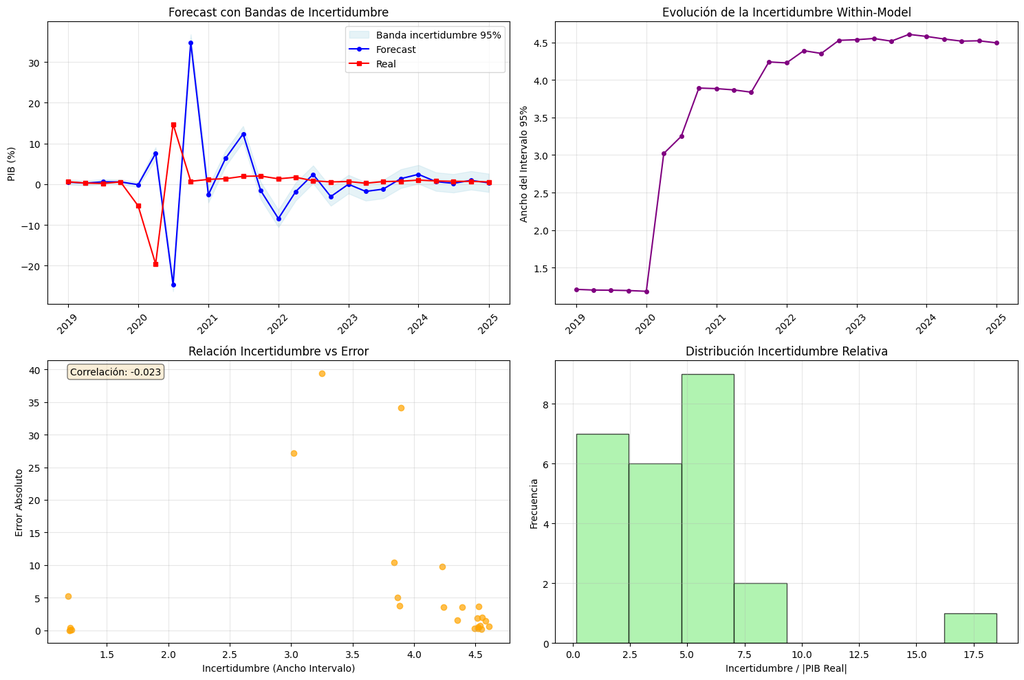

```
ANÁLISIS DE INCERTIDUMBRE:
Correlación incertidumbre-error: -0.023

Períodos de MAYOR incertidumbre:
  2023Q4: 4.607 (error real: 0.638)
  2024Q1: 4.580 (error real: 1.410)
  2023Q2: 4.553 (error real: 2.007)

Períodos de MENOR incertidumbre:
  2020Q1: 1.184 (error real: 5.213)
  2019Q4: 1.194 (error real: 0.003)
  2019Q3: 1.199 (error real: 0.408)

TABLA COMPLETA CON INCERTIDUMBRE:
        forecast   actual    error  abs_error  uncertainty  \
period
2019Q1    0.5243   0.6112  -0.0869     0.0869       1.2100
2019Q2    0.2692   0.2879  -0.0187     0.0187       1.2011
2019Q3    0.5996   0.1914   0.4082     0.4082       1.1989
2019Q4    0.5661   0.5690  -0.0029     0.0029       1.1944
2020Q1   -0.1034  -5.3162   5.2128     5.2128       1.1845
2020Q2    7.5680 -19.5898  27.1577    27.1577       3.0201
2020Q3  -24.6637  14.7577 -39.4214    39.4214       3.2490
2020Q4   34.8492   0.7230  34.1262    34.1262       3.8924
2021Q1   -2.5615   1.1946  -3.7561     3.7561       3.8849
2021Q2    6.3950   1.3616   5.0335     5.0335       3.8677
2021Q3   12.3536   1.9520  10.4016    10.4016       3.8372
2021Q4   -1.5759   2.0111  -3.5870     3.5870       4.2406
2022Q1   -8.4309   1.3342  -9.7651     9.7651       4.2276
2022Q2   -1.8088   1.7100  -3.5188     3.5188       4.3903
2022Q3    2.4248   0.8508   1.5741     1.5741       4.3536
2022Q4   -3.0295   0.5694  -3.5989     3.5989       4.5281
2023Q1    0.0019   0.6698  -0.6679     0.6679       4.5366
2023Q2   -1.7615   0.2459  -2.0074     2.0074       4.5529
2023Q3   -1.2032   0.6565  -1.8597     1.8597       4.5173
2023Q4    1.3705   0.7321   0.6385     0.6385       4.6074
2024Q1    2.4292   1.0197   1.4095     1.4095       4.5802
2024Q2    0.6393   0.8117  -0.1724     0.1724       4.5460
2024Q3    0.2273   0.7109  -0.4836     0.4836       4.5176
2024Q4    0.9508   0.7099   0.2410     0.2410       4.5222
```

[output cut: 14 more lines]

```
2021Q3                1.9658
2021Q4                2.1086
2022Q1                3.1685
2022Q2                2.5674
2022Q3                5.1172
2022Q4                7.9523
2023Q1                6.7732
2023Q2               18.5126
2023Q3                6.8809
2023Q4                6.2938
2024Q1                4.4916
2024Q2                5.6008
2024Q3                6.3552
2024Q4                6.3705
2025Q1                7.9368
```

```python
def calculate_uncertainty_from_results(results_df, best_data, gdp_column):
   """Calcula incertidumbre within-model retrospectiva"""

   print("Calculando incertidumbre within-model...")
   print("=" * 50)

   uncertainty_measures = []

   for i, (period, row) in enumerate(results_df.iterrows()):
       train_end = period - 1
       train_data = best_data.loc[:train_end]

       print(f"{i+1}/{len(results_df)}: Calculando incertidumbre para {period}")

       try:
           # Re-estimar modelo
           model = VAR(train_data)

           # Usar los mismos lags que en el forecast original
           optimal_lags = min(2, len(train_data)//15) or 1
           var_fitted = model.fit(optimal_lags)

           # Intervalos de confianza al 95%
           forecast_err, lower, upper = var_fitted.forecast_interval(
               train_data.values, 1, alpha=0.05
           )

           # Ancho del intervalo para PIB (primera variable)
           interval_width = upper[0, 0] - lower[0, 0]
           uncertainty_measures.append(interval_width)

           print(f"  Intervalo: [{lower[0, 0]:.3f}, {upper[0, 0]:.3f}] | Ancho: {interval_width:.3f}")

       except Exception as e:
           print(f"  ❌ Error: {str(e)[:30]}...")
           uncertainty_measures.append(np.nan)

   # Añadir al DataFrame
   results_df['uncertainty'] = uncertainty_measures
   results_df['relative_uncertainty'] = results_df['uncertainty'] / abs(results_df['actual'])

   print(f"\nRESUMEN DE INCERTIDUMBRE:")
   print(f"Incertidumbre promedio: {results_df['uncertainty'].mean():.3f}")
   print(f"Incertidumbre mínima: {results_df['uncertainty'].min():.3f}")
   print(f"Incertidumbre máxima: {results_df['uncertainty'].max():.3f}")
   print(f"Incertidumbre relativa promedio: {results_df['relative_uncertainty'].mean():.1%}")

   return results_df

def plot_uncertainty_analysis(results_df):
   """Visualiza análisis de incertidumbre"""

   fig, axes = plt.subplots(2, 2, figsize=(15, 10))

   # Gráfico 1: Forecast con bandas de incertidumbre
   ax1 = axes[0, 0]

   # Calcular bandas (asumiendo distribución normal)
   upper_band = results_df['forecast'] + 1.96 * results_df['uncertainty']/3.92  # aproximación
   lower_band = results_df['forecast'] - 1.96 * results_df['uncertainty']/3.92

   ax1.fill_between(results_df.index.to_timestamp(), lower_band, upper_band,
                    alpha=0.3, color='lightblue', label='Banda incertidumbre 95%')
   ax1.plot(results_df.index.to_timestamp(), results_df['forecast'], 'b-o', label='Forecast', markersize=4)
   ax1.plot(results_df.index.to_timestamp(), results_df['actual'], 'r-s', label='Real', markersize=4)
   ax1.set_title('Forecast con Bandas de Incertidumbre')
   ax1.set_ylabel('PIB (%)')
   ax1.legend()
   ax1.grid(True, alpha=0.3)
   ax1.tick_params(axis='x', rotation=45)

   # Gráfico 2: Evolución de la incertidumbre
   ax2 = axes[0, 1]
   ax2.plot(results_df.index.to_timestamp(), results_df['uncertainty'], 'purple', marker='o', markersize=4)
   ax2.set_title('Evolución de la Incertidumbre Within-Model')
   ax2.set_ylabel('Ancho del Intervalo 95%')
   ax2.grid(True, alpha=0.3)
   ax2.tick_params(axis='x', rotation=45)

   # Gráfico 3: Incertidumbre vs Error Absoluto
   ax3 = axes[1, 0]
   ax3.scatter(results_df['uncertainty'], results_df['abs_error'], alpha=0.7, color='orange')
   ax3.set_xlabel('Incertidumbre (Ancho Intervalo)')
   ax3.set_ylabel('Error Absoluto')
   ax3.set_title('Relación Incertidumbre vs Error')
   ax3.grid(True, alpha=0.3)

   # Calcular correlación
   corr = results_df['uncertainty'].corr(results_df['abs_error'])
   ax3.text(0.05, 0.95, f'Correlación: {corr:.3f}', transform=ax3.transAxes,
            bbox=dict(boxstyle="round", facecolor='wheat', alpha=0.5))

   # Gráfico 4: Distribución de incertidumbre relativa
   ax4 = axes[1, 1]
   ax4.hist(results_df['relative_uncertainty'].dropna(), bins=8, alpha=0.7,
            color='lightgreen', edgecolor='black')
   ax4.set_title('Distribución Incertidumbre Relativa')
   ax4.set_xlabel('Incertidumbre / |PIB Real|')
   ax4.set_ylabel('Frecuencia')
   ax4.grid(True, alpha=0.3)

   plt.tight_layout()
   plt.show()

   # Análisis adicional
   print(f"\nANÁLISIS DE INCERTIDUMBRE:")
   print(f"Correlación incertidumbre-error: {corr:.3f}")

   # Períodos de mayor incertidumbre
   high_uncertainty = results_df.nlargest(3, 'uncertainty')
   print(f"\nPeríodos de MAYOR incertidumbre:")
   for period, row in high_uncertainty.iterrows():
       print(f"  {period}: {row['uncertainty']:.3f} (error real: {row['abs_error']:.3f})")

   # Períodos de menor incertidumbre
   low_uncertainty = results_df.nsmallest(3, 'uncertainty')
   print(f"\nPeríodos de MENOR incertidumbre:")
   for period, row in low_uncertainty.iterrows():
       print(f"  {period}: {row['uncertainty']:.3f} (error real: {row['abs_error']:.3f})")

# Ejecutar cálculo de incertidumbre
results_with_uncertainty = calculate_uncertainty_from_results(results_df, best_data, gdp_column)

# Visualizar
plot_uncertainty_analysis(results_with_uncertainty)

# Mostrar tabla completa
print(f"\nTABLA COMPLETA CON INCERTIDUMBRE:")
display_cols = ['forecast', 'actual', 'error', 'abs_error', 'uncertainty', 'relative_uncertainty']
print(results_with_uncertainty[display_cols].round(4))
```

# Random Forest

```
Ejecutando evaluación Random Forest...
Evaluando Random Forest desde 2019Q1 hasta 2025Q1
============================================================

1/25: Prediciendo 2019Q1 usando datos hasta 2018Q4
  ✅ Forecast: +0.7149 | Real: +0.6112 | Error: +0.1037

2/25: Prediciendo 2019Q2 usando datos hasta 2019Q1
  ✅ Forecast: +0.6764 | Real: +0.2879 | Error: +0.3884

3/25: Prediciendo 2019Q3 usando datos hasta 2019Q2
  ✅ Forecast: +0.6204 | Real: +0.1914 | Error: +0.4290

4/25: Prediciendo 2019Q4 usando datos hasta 2019Q3
  ✅ Forecast: +0.3763 | Real: +0.5690 | Error: -0.1927

5/25: Prediciendo 2020Q1 usando datos hasta 2019Q4
  ✅ Forecast: +0.3974 | Real: -5.3162 | Error: +5.7136

6/25: Prediciendo 2020Q2 usando datos hasta 2020Q1
  ✅ Forecast: -2.6176 | Real: -19.5898 | Error: +16.9721

7/25: Prediciendo 2020Q3 usando datos hasta 2020Q2
  ✅ Forecast: -12.4625 | Real: +14.7577 | Error: -27.2202

8/25: Prediciendo 2020Q4 usando datos hasta 2020Q3
  ✅ Forecast: +1.1688 | Real: +0.7230 | Error: +0.4458

9/25: Prediciendo 2021Q1 usando datos hasta 2020Q4
  ✅ Forecast: +0.7402 | Real: +1.1946 | Error: -0.4543

10/25: Prediciendo 2021Q2 usando datos hasta 2021Q1
  ✅ Forecast: +0.4264 | Real: +1.3616 | Error: -0.9352

11/25: Prediciendo 2021Q3 usando datos hasta 2021Q2
  ✅ Forecast: +0.6484 | Real: +1.9520 | Error: -1.3036

12/25: Prediciendo 2021Q4 usando datos hasta 2021Q3
  ✅ Forecast: +0.8988 | Real: +2.0111 | Error: -1.1123

```

[output cut: 34 more lines]

```
  ✅ Forecast: +0.7765 | Real: +0.7099 | Error: +0.0666

25/25: Prediciendo 2025Q1 usando datos hasta 2024Q4
  ✅ Forecast: +0.7685 | Real: +0.5662 | Error: +0.2022

============================================================
RESULTADOS RANDOM FOREST:
Períodos evaluados: 25
Error Absoluto Medio (MAE): 2.3425
Error Cuadrático Medio (RMSE): 6.5354

COMPARACIÓN VAR vs RANDOM FOREST
==================================================
MAE  - VAR: 6.2149 | RF: 2.3425 | Mejora: +62.3%
RMSE - VAR: 12.2929 | RF: 6.5354 | Mejora: +46.8%
```

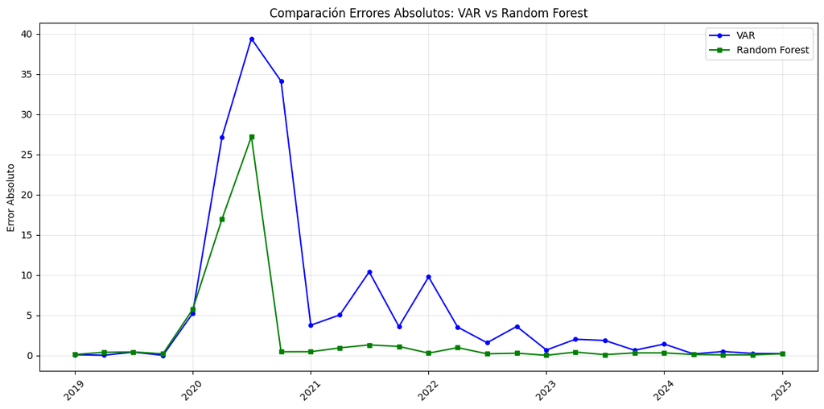

```python
from sklearn.ensemble import RandomForestRegressor
from sklearn.metrics import mean_absolute_error, mean_squared_error

def create_lagged_features(data, lags=3):
    """Crea features con lags para Random Forest"""

    features = []
    target = []

    for i in range(lags, len(data)):
        # Features: lags de todas las variables
        feature_row = []
        for lag in range(1, lags + 1):
            feature_row.extend(data.iloc[i-lag].values)

        features.append(feature_row)
        target.append(data.iloc[i, 0])  # PIB es la primera columna

    return np.array(features), np.array(target)

def rolling_rf_evaluation(best_data, gdp_column, start_eval='2019Q1', end_eval='2025Q1'):
    """Evaluación rolling del Random Forest"""

    start_period = pd.Period(start_eval, freq='Q')
    end_period = pd.Period(end_eval, freq='Q')
    eval_periods = pd.period_range(start=start_period, end=end_period, freq='Q')

    results = []

    print(f"Evaluando Random Forest desde {start_eval} hasta {end_eval}")
    print("=" * 60)

    for i, target_period in enumerate(eval_periods):
        train_end = target_period - 1
        print(f"\n{i+1}/{len(eval_periods)}: Prediciendo {target_period} usando datos hasta {train_end}")

        # Datos de entrenamiento
        train_data = best_data.loc[:train_end].copy()

        if len(train_data) < 10:
            print(f"  ⚠️  Pocos datos: {len(train_data)}")
            continue

        try:
            # Crear features con lags
            X_train, y_train = create_lagged_features(train_data, lags=2)

            if len(X_train) < 5:
                print(f"  ⚠️  Muy pocos datos después de lags: {len(X_train)}")
                continue

            # Entrenar Random Forest
            rf = RandomForestRegressor(
                n_estimators=50,
                max_depth=3,
                random_state=42,
                min_samples_split=2,
                min_samples_leaf=1
            )

            rf.fit(X_train, y_train)

            # Preparar datos para forecast
            last_data = train_data.iloc[-2:].values.flatten()  # Últimos 2 períodos
            forecast = rf.predict(last_data.reshape(1, -1))[0]

            # Valor real
            if target_period in best_data.index:
                gdp_real = best_data.loc[target_period, gdp_column]
                error = forecast - gdp_real

                results.append({
                    'period': target_period,
                    'forecast': forecast,
                    'actual': gdp_real,
                    'error': error,
                    'abs_error': abs(error),
                    'squared_error': error**2,
                    'train_obs': len(X_train)
                })

                print(f"  ✅ Forecast: {forecast:+.4f} | Real: {gdp_real:+.4f} | Error: {error:+.4f}")
            else:
                print(f"  ⚠️  No hay dato real para {target_period}")

        except Exception as e:
            print(f"  ❌ Error: {str(e)[:50]}...")

    if results:
        results_df = pd.DataFrame(results)
        results_df.set_index('period', inplace=True)

        # Calcular métricas
        mae = results_df['abs_error'].mean()
        rmse = np.sqrt(results_df['squared_error'].mean())

        print(f"\n" + "=" * 60)
        print(f"RESULTADOS RANDOM FOREST:")
        print(f"Períodos evaluados: {len(results_df)}")
        print(f"Error Absoluto Medio (MAE): {mae:.4f}")
        print(f"Error Cuadrático Medio (RMSE): {rmse:.4f}")

        return results_df, mae, rmse
    else:
        print("❌ No se obtuvieron resultados")
        return None, None, None

# Ejecutar Random Forest
print("Ejecutando evaluación Random Forest...")
rf_results, rf_mae, rf_rmse = rolling_rf_evaluation(best_data, gdp_column)

if rf_results is not None:
    # Comparar VAR vs Random Forest
    print(f"\nCOMPARACIÓN VAR vs RANDOM FOREST")
    print("=" * 50)

    var_mae = results_df['abs_error'].mean()
    var_rmse = np.sqrt(results_df['squared_error'].mean())

    print(f"MAE  - VAR: {var_mae:.4f} | RF: {rf_mae:.4f} | Mejora: {((var_mae-rf_mae)/var_mae)*100:+.1f}%")
    print(f"RMSE - VAR: {var_rmse:.4f} | RF: {rf_rmse:.4f} | Mejora: {((var_rmse-rf_rmse)/var_rmse)*100:+.1f}%")

    # Gráfico rápido
    plt.figure(figsize=(12, 6))
    plt.plot(results_df.index.to_timestamp(), results_df['abs_error'], 'b-o', label='VAR', markersize=4)
    plt.plot(rf_results.index.to_timestamp(), rf_results['abs_error'], 'g-s', label='Random Forest', markersize=4)
    plt.title('Comparación Errores Absolutos: VAR vs Random Forest')
    plt.ylabel('Error Absoluto')
    plt.legend()
    plt.grid(True, alpha=0.3)
    plt.xticks(rotation=45)
    plt.tight_layout()
    plt.show()
```

# Arima

```
Ejecutando evaluación ARIMA...
Evaluando ARIMA desde 2019Q1 hasta 2025Q1
============================================================

1/25: Prediciendo 2019Q1 usando datos hasta 2018Q4
  📈 Mejor ARIMA(1, 0, 0), AIC: 89.52
  ✅ Forecast: +0.5427 | Real: +0.6112 | Error: -0.0686

2/25: Prediciendo 2019Q2 usando datos hasta 2019Q1
  📈 Mejor ARIMA(1, 0, 0), AIC: 89.70
  ✅ Forecast: +0.5648 | Real: +0.2879 | Error: +0.2769

3/25: Prediciendo 2019Q3 usando datos hasta 2019Q2
  📈 Mejor ARIMA(1, 0, 0), AIC: 90.26
  ✅ Forecast: +0.3140 | Real: +0.1914 | Error: +0.1226

4/25: Prediciendo 2019Q4 usando datos hasta 2019Q3
  📈 Mejor ARIMA(1, 0, 0), AIC: 90.48
  ✅ Forecast: +0.2387 | Real: +0.5690 | Error: -0.3303

5/25: Prediciendo 2020Q1 usando datos hasta 2019Q4
  📈 Mejor ARIMA(1, 0, 0), AIC: 91.20
  ✅ Forecast: +0.5310 | Real: -5.3162 | Error: +5.8472

6/25: Prediciendo 2020Q2 usando datos hasta 2020Q1
  📈 Mejor ARIMA(0, 1, 1), AIC: 183.79
  ✅ Forecast: -3.3553 | Real: -19.5898 | Error: +16.2345

7/25: Prediciendo 2020Q3 usando datos hasta 2020Q2
  📈 Mejor ARIMA(1, 1, 1), AIC: 263.71
  ✅ Forecast: -35.1814 | Real: +14.7577 | Error: -49.9392

8/25: Prediciendo 2020Q4 usando datos hasta 2020Q3
  📈 Mejor ARIMA(2, 1, 1), AIC: 387.33
  ✅ Forecast: +0.9972 | Real: +0.7230 | Error: +0.2742

9/25: Prediciendo 2021Q1 usando datos hasta 2020Q4
  📈 Mejor ARIMA(2, 1, 1), AIC: 391.21
  ✅ Forecast: -17.7674 | Real: +1.1946 | Error: -18.9619

```

[output cut: 69 more lines]

```

Órdenes ARIMA más frecuentes:
  (0, 0, 1): 16 veces
  (1, 0, 0): 5 veces
  (2, 1, 1): 2 veces

COMPARACIÓN DE 3 MODELOS
============================================================
                  MAE     RMSE  Periods
VAR            6.2149  12.2929     25.0
Random Forest  2.3425   6.5354     25.0
ARIMA          4.2641  11.2650     25.0

🏆 Mejor MAE: Random Forest
🏆 Mejor RMSE: Random Forest
```

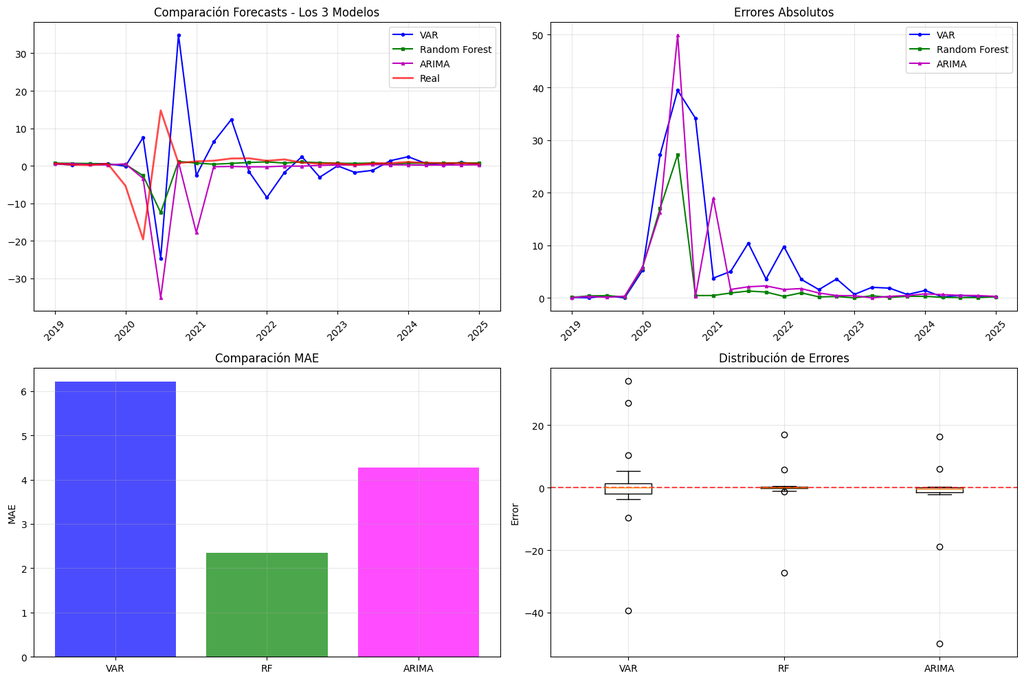

```
🎯 RANKING DE MODELOS:
1. Random Forest: MAE=2.3425, RMSE=6.5354
2. ARIMA: MAE=4.2641, RMSE=11.2650
3. VAR: MAE=6.2149, RMSE=12.2929
```

```python
from statsmodels.tsa.arima.model import ARIMA
from statsmodels.tsa.stattools import adfuller

def rolling_arima_evaluation(best_data, gdp_column, start_eval='2019Q1', end_eval='2025Q1'):
   """Evaluación rolling del ARIMA (solo PIB)"""

   start_period = pd.Period(start_eval, freq='Q')
   end_period = pd.Period(end_eval, freq='Q')
   eval_periods = pd.period_range(start=start_period, end=end_period, freq='Q')

   results = []

   print(f"Evaluando ARIMA desde {start_eval} hasta {end_eval}")
   print("=" * 60)

   # Solo usar PIB (univariante)
   gdp_series = best_data[gdp_column]

   for i, target_period in enumerate(eval_periods):
       train_end = target_period - 1
       print(f"\n{i+1}/{len(eval_periods)}: Prediciendo {target_period} usando datos hasta {train_end}")

       # Datos de entrenamiento (solo PIB)
       train_data = gdp_series.loc[:train_end].dropna()

       if len(train_data) < 10:
           print(f"  ⚠️  Pocos datos: {len(train_data)}")
           continue

       try:
           # Selección automática de parámetros ARIMA
           # Probar diferentes combinaciones (p,d,q)
           best_aic = np.inf
           best_order = (1,1,1)

           # Grid search simple
           for p in range(0, 3):
               for d in range(0, 2):
                   for q in range(0, 3):
                       try:
                           temp_model = ARIMA(train_data, order=(p,d,q))
                           temp_fitted = temp_model.fit()
                           if temp_fitted.aic < best_aic:
                               best_aic = temp_fitted.aic
                               best_order = (p,d,q)
                       except:
                           continue

           print(f"  📈 Mejor ARIMA{best_order}, AIC: {best_aic:.2f}")

           # Estimar modelo final
           arima_model = ARIMA(train_data, order=best_order)
           arima_fitted = arima_model.fit()

           # Forecast
           forecast_result = arima_fitted.forecast(steps=1)
           gdp_forecast = forecast_result.iloc[0] if hasattr(forecast_result, 'iloc') else forecast_result[0]

           # Valor real
           if target_period in best_data.index:
               gdp_real = best_data.loc[target_period, gdp_column]
               error = gdp_forecast - gdp_real

               results.append({
                   'period': target_period,
                   'forecast': gdp_forecast,
                   'actual': gdp_real,
                   'error': error,
                   'abs_error': abs(error),
                   'squared_error': error**2,
                   'train_obs': len(train_data),
                   'arima_order': str(best_order),
                   'aic': best_aic
               })

               print(f"  ✅ Forecast: {gdp_forecast:+.4f} | Real: {gdp_real:+.4f} | Error: {error:+.4f}")
           else:
               print(f"  ⚠️  No hay dato real para {target_period}")

       except Exception as e:
           print(f"  ❌ Error: {str(e)[:50]}...")

   if results:
       results_df = pd.DataFrame(results)
       results_df.set_index('period', inplace=True)

       # Calcular métricas
       mae = results_df['abs_error'].mean()
       rmse = np.sqrt(results_df['squared_error'].mean())

       print(f"\n" + "=" * 60)
       print(f"RESULTADOS ARIMA:")
       print(f"Períodos evaluados: {len(results_df)}")
       print(f"Error Absoluto Medio (MAE): {mae:.4f}")
       print(f"Error Cuadrático Medio (RMSE): {rmse:.4f}")

       # Mostrar órdenes ARIMA más usados
       order_counts = results_df['arima_order'].value_counts()
       print(f"\nÓrdenes ARIMA más frecuentes:")
       for order, count in order_counts.head(3).items():
           print(f"  {order}: {count} veces")

       return results_df, mae, rmse
   else:
       print("❌ No se obtuvieron resultados")
       return None, None, None

def compare_three_models(var_results, rf_results, arima_results):
   """Compara los 3 modelos: VAR, RF y ARIMA"""

   print(f"\nCOMPARACIÓN DE 3 MODELOS")
   print("=" * 60)

   # Métricas
   models = {
       'VAR': var_results,
       'Random Forest': rf_results,
       'ARIMA': arima_results
   }

   comparison = {}
   for name, results in models.items():
       comparison[name] = {
           'MAE': results['abs_error'].mean(),
           'RMSE': np.sqrt(results['squared_error'].mean()),
           'Periods': len(results)
       }

   # Tabla comparativa
   comp_df = pd.DataFrame(comparison).T
   print(comp_df.round(4))

   # Encontrar el mejor modelo
   best_mae = comp_df['MAE'].idxmin()
   best_rmse = comp_df['RMSE'].idxmin()

   print(f"\n🏆 Mejor MAE: {best_mae}")
   print(f"🏆 Mejor RMSE: {best_rmse}")

   # Gráfico comparativo
   fig, axes = plt.subplots(2, 2, figsize=(15, 10))

   # Períodos comunes
   common_periods = var_results.index.intersection(rf_results.index).intersection(arima_results.index)

   # Gráfico 1: Todos los forecasts
   ax1 = axes[0, 0]
   ax1.plot(common_periods.to_timestamp(),
            [var_results.loc[p, 'forecast'] for p in common_periods],
            'b-o', label='VAR', markersize=3)
   ax1.plot(common_periods.to_timestamp(),
            [rf_results.loc[p, 'forecast'] for p in common_periods],
            'g-s', label='Random Forest', markersize=3)
   ax1.plot(common_periods.to_timestamp(),
            [arima_results.loc[p, 'forecast'] for p in common_periods],
            'm-^', label='ARIMA', markersize=3)
   ax1.plot(common_periods.to_timestamp(),
            [var_results.loc[p, 'actual'] for p in common_periods],
            'r-', label='Real', linewidth=2, alpha=0.7)
   ax1.set_title('Comparación Forecasts - Los 3 Modelos')
   ax1.legend()
   ax1.grid(True, alpha=0.3)
   ax1.tick_params(axis='x', rotation=45)

   # Gráfico 2: Errores absolutos
   ax2 = axes[0, 1]
   ax2.plot(common_periods.to_timestamp(),
            [var_results.loc[p, 'abs_error'] for p in common_periods],
            'b-o', label='VAR', markersize=3)
   ax2.plot(common_periods.to_timestamp(),
            [rf_results.loc[p, 'abs_error'] for p in common_periods],
            'g-s', label='Random Forest', markersize=3)
   ax2.plot(common_periods.to_timestamp(),
            [arima_results.loc[p, 'abs_error'] for p in common_periods],
            'm-^', label='ARIMA', markersize=3)
   ax2.set_title('Errores Absolutos')
   ax2.legend()
   ax2.grid(True, alpha=0.3)
   ax2.tick_params(axis='x', rotation=45)

   # Gráfico 3: Distribución MAE
   ax3 = axes[1, 0]
   mae_values = [comp_df.loc['VAR', 'MAE'], comp_df.loc['Random Forest', 'MAE'], comp_df.loc['ARIMA', 'MAE']]
   colors = ['blue', 'green', 'magenta']
   ax3.bar(['VAR', 'RF', 'ARIMA'], mae_values, color=colors, alpha=0.7)
   ax3.set_title('Comparación MAE')
   ax3.set_ylabel('MAE')
   ax3.grid(True, alpha=0.3)

   # Gráfico 4: Box plot errores
   ax4 = axes[1, 1]
   error_data = [
       [var_results.loc[p, 'error'] for p in common_periods],
       [rf_results.loc[p, 'error'] for p in common_periods],
       [arima_results.loc[p, 'error'] for p in common_periods]
   ]
   ax4.boxplot(error_data, labels=['VAR', 'RF', 'ARIMA'])
   ax4.set_title('Distribución de Errores')
   ax4.set_ylabel('Error')
   ax4.grid(True, alpha=0.3)
   ax4.axhline(y=0, color='red', linestyle='--', alpha=0.7)

   plt.tight_layout()
   plt.show()

   return comp_df, common_periods

# Ejecutar ARIMA
print("Ejecutando evaluación ARIMA...")
arima_results, arima_mae, arima_rmse = rolling_arima_evaluation(best_data, gdp_column)

if arima_results is not None:
   # Comparar los 3 modelos
   comparison_table, common_periods = compare_three_models(results_df, rf_results, arima_results)

   print(f"\n🎯 RANKING DE MODELOS:")
   ranking = comparison_table.sort_values('MAE')
   for i, (model, row) in enumerate(ranking.iterrows()):
       print(f"{i+1}. {model}: MAE={row['MAE']:.4f}, RMSE={row['RMSE']:.4f}")
```

# 🧠 **Módulo LSTM (Long Short-Term Memory)**

Este módulo implementa **redes neuronales LSTM** para forecasting del PIB, añadiendo capacidades de **deep learning** al framework multidimensional de incertidumbre económica.

## 🎯 **Características del Modelo LSTM**

```python
import numpy as np
import pandas as pd
from sklearn.preprocessing import MinMaxScaler
from sklearn.metrics import mean_absolute_error, mean_squared_error

# Importaciones de TensorFlow (ya verificadas)
import tensorflow as tf
from tensorflow.keras.models import Sequential
from tensorflow.keras.layers import LSTM, Dense, Dropout
from tensorflow.keras.optimizers import Adam
from tensorflow.keras.callbacks import EarlyStopping, ReduceLROnPlateau

print("🧠 Módulo LSTM - Framework de Incertidumbre Económica")
print("=" * 60)

class LSTMForecaster:
    """Modelo LSTM para forecasting económico con incertidumbre"""

    def __init__(self, sequence_length=6, lstm_units=32, dropout_rate=0.2,
                 learning_rate=0.001, random_state=42):
        self.sequence_length = sequence_length
        self.lstm_units = lstm_units
        self.dropout_rate = dropout_rate
        self.learning_rate = learning_rate
        self.random_state = random_state

        # Reproducibilidad
        np.random.seed(random_state)
        tf.random.set_seed(random_state)

        self.model = None
        self.scaler_X = MinMaxScaler()
        self.scaler_y = MinMaxScaler()
        self.is_fitted = False

    def _create_model(self, n_features):
        """Crea arquitectura LSTM optimizada para datos económicos"""
        model = Sequential([
            LSTM(self.lstm_units, return_sequences=True,
                 input_shape=(self.sequence_length, n_features)),
            Dropout(self.dropout_rate),

            LSTM(self.lstm_units, return_sequences=False),
            Dropout(self.dropout_rate),

            Dense(16, activation='relu'),
            Dropout(self.dropout_rate / 2),
            Dense(1)
        ])

        optimizer = Adam(learning_rate=self.learning_rate)
        model.compile(optimizer=optimizer, loss='mse', metrics=['mae'])

        return model

    def _create_sequences(self, data, target_col_idx=0):
        """Crea secuencias temporales para LSTM"""
        X, y = [], []

        for i in range(self.sequence_length, len(data)):
            X.append(data[i-self.sequence_length:i])
            y.append(data[i, target_col_idx])

        return np.array(X), np.array(y)

    def fit(self, data, gdp_col, epochs=30, batch_size=8, validation_split=0.2,
            verbose=0, patience=10):
        """Entrena el modelo LSTM"""

        # Preparar datos
        data_values = data.values.astype(np.float32)
        data_scaled = self.scaler_X.fit_transform(data_values)

        # Normalizar target por separado
        pib_values = data_values[:, 0].reshape(-1, 1)
        self.scaler_y.fit(pib_values)

        # Crear secuencias
        X, y = self._create_sequences(data_scaled, target_col_idx=0)

        if len(X) < 10:
            raise ValueError("Datos insuficientes para LSTM")

        # Crear y compilar modelo
        self.model = self._create_model(n_features=data.shape[1])

        # Callbacks para entrenamiento robusto
        callbacks = [
            EarlyStopping(monitor='val_loss', patience=patience,
                         restore_best_weights=True, verbose=0),
            ReduceLROnPlateau(monitor='val_loss', factor=0.5,
                            patience=patience//2, min_lr=1e-6, verbose=0)
        ]

        # Entrenar
        history = self.model.fit(
            X, y, epochs=epochs, batch_size=batch_size,
            validation_split=validation_split, callbacks=callbacks,
            verbose=verbose, shuffle=True
        )

        self.is_fitted = True
        return history

    def predict_with_uncertainty(self, data, n_samples=50):
        """Predicción con intervalos de incertidumbre (Monte Carlo Dropout)"""
        if not self.is_fitted:
            raise ValueError("Modelo no entrenado")

        data_values = data.values.astype(np.float32)
        data_scaled = self.scaler_X.transform(data_values)
        X_last = data_scaled[-self.sequence_length:].reshape(1, self.sequence_length, -1)

        # Monte Carlo Dropout
        predictions_scaled = []
        for _ in range(n_samples):
            pred_scaled = self.model(X_last, training=True)  # Dropout activo
            predictions_scaled.append(pred_scaled.numpy()[0, 0])

        predictions_scaled = np.array(predictions_scaled).reshape(-1, 1)
        predictions = self.scaler_y.inverse_transform(predictions_scaled).flatten()

        # Estadísticas
        mean_pred = np.mean(predictions)
        std_pred = np.std(predictions)
        percentiles = np.percentile(predictions, [5, 25, 50, 75, 95])

        return {
            'mean': mean_pred,
            'std': std_pred,
            'interval_95': (percentiles[0], percentiles[4]),
            'interval_width': percentiles[4] - percentiles[0],
            'predictions': predictions
        }

def rolling_lstm_evaluation(best_data, gdp_column, start_eval='2019Q1', end_eval='2025Q1'):
    """Evaluación rolling del LSTM compatible con el framework existente"""

    start_period = pd.Period(start_eval, freq='Q')
    end_period = pd.Period(end_eval, freq='Q')
    eval_periods = pd.period_range(start=start_period, end=end_period, freq='Q')

    results = []

    print(f"🧠 Evaluando LSTM desde {start_eval} hasta {end_eval}")
    print("=" * 60)

    for i, target_period in enumerate(eval_periods):
        train_end = target_period - 1
        print(f"\n{i+1}/{len(eval_periods)}: Prediciendo {target_period} usando datos hasta {train_end}")

        # Datos de entrenamiento
        train_data = best_data.loc[:train_end]

        # Verificar suficientes datos (6 + 10 mínimo)
        if len(train_data) < 16:
            print(f"   ⚠ Pocos datos: {len(train_data)}")
            continue

        try:
            # Crear modelo LSTM
            lstm_model = LSTMForecaster(
                sequence_length=6,  # 1.5 años de historia
                lstm_units=24,      # Reducido para datasets pequeños
                dropout_rate=0.2,
                learning_rate=0.001,
                random_state=42
            )

            # Entrenar con configuración ligera
            history = lstm_model.fit(
                train_data, gdp_column,
                epochs=25,           # Reducido para velocidad
                batch_size=4,        # Pequeño para datos trimestrales
                validation_split=0.15,
                verbose=0,           # Sin output
                patience=8
            )

            # Predicción con incertidumbre
            uncertainty_results = lstm_model.predict_with_uncertainty(
                train_data, n_samples=30  # Reducido para velocidad
            )

            lstm_forecast = uncertainty_results['mean']
            lstm_uncertainty = uncertainty_results['interval_width']

            # Valor real y error
            if target_period in best_data.index:
                gdp_real = best_data.loc[target_period, gdp_column]
                error = lstm_forecast - gdp_real

                results.append({
                    'period': target_period,
                    'forecast': lstm_forecast,
                    'actual': gdp_real,
                    'error': error,
                    'abs_error': abs(error),
                    'squared_error': error**2,
                    'uncertainty': lstm_uncertainty,
                    'train_obs': len(train_data),
                    'epochs_trained': len(history.history['loss'])
                })

                print(f"   ✅ Forecast: {lstm_forecast:+.4f} | Real: {gdp_real:+.4f} | Error: {error:+.4f}")
                print(f"   📊 Incertidumbre (95%): ±{lstm_uncertainty/2:.3f}")
            else:
                print(f"   ⚠ No hay dato real para {target_period}")

        except Exception as e:
            print(f"   ❌ Error: {str(e)[:40]}...")
            continue

    if results:
        results_df = pd.DataFrame(results)
        results_df.set_index('period', inplace=True)

        # Métricas
        mae = results_df['abs_error'].mean()
        rmse = np.sqrt(results_df['squared_error'].mean())
        avg_uncertainty = results_df['uncertainty'].mean()

        print(f"\n" + "=" * 60)
        print(f"RESULTADOS LSTM:")
        print(f"Períodos evaluados: {len(results_df)}")
        print(f"Error Absoluto Medio (MAE): {mae:.4f}")
        print(f"Error Cuadrático Medio (RMSE): {rmse:.4f}")
        print(f"Incertidumbre promedio: {avg_uncertainty:.4f}")

        return results_df, mae, rmse
    else:
        print("❌ No se obtuvieron resultados LSTM")
        return None, None, None

# =============================================================================
# 🚀 EJECUTAR EVALUACIÓN LSTM
# =============================================================================

print("Iniciando evaluación LSTM...")
lstm_results, lstm_mae, lstm_rmse = rolling_lstm_evaluation(best_data, gdp_column)

if lstm_results is not None:
    print(f"\n🎯 LSTM COMPLETADO EXITOSAMENTE!")
    print(f"✅ MAE: {lstm_mae:.4f}")
    print(f"✅ RMSE: {lstm_rmse:.4f}")

    # Mostrar algunos resultados
    print(f"\nPrimeros resultados LSTM:")
    display_cols = ['forecast', 'actual', 'error', 'abs_error', 'uncertainty']
    print(lstm_results[display_cols].head().round(4))
else:
    print("❌ LSTM no se pudo ejecutar")
```

```
🧠 Módulo LSTM - Framework de Incertidumbre Económica
============================================================
Iniciando evaluación LSTM...
🧠 Evaluando LSTM desde 2019Q1 hasta 2025Q1
============================================================

1/25: Prediciendo 2019Q1 usando datos hasta 2018Q4
   ✅ Forecast: +0.6968 | Real: +0.6112 | Error: +0.0856
   📊 Incertidumbre (95%): ±1.043

2/25: Prediciendo 2019Q2 usando datos hasta 2019Q1
   ✅ Forecast: +0.6723 | Real: +0.2879 | Error: +0.3844
   📊 Incertidumbre (95%): ±0.965

3/25: Prediciendo 2019Q3 usando datos hasta 2019Q2
   ✅ Forecast: +0.6386 | Real: +0.1914 | Error: +0.4472
   📊 Incertidumbre (95%): ±0.960

4/25: Prediciendo 2019Q4 usando datos hasta 2019Q3
   ✅ Forecast: +0.7283 | Real: +0.5690 | Error: +0.1593
   📊 Incertidumbre (95%): ±0.772

5/25: Prediciendo 2020Q1 usando datos hasta 2019Q4
   ✅ Forecast: +0.7130 | Real: -5.3162 | Error: +6.0292
   📊 Incertidumbre (95%): ±0.832

6/25: Prediciendo 2020Q2 usando datos hasta 2020Q1
   ✅ Forecast: +0.0701 | Real: -19.5898 | Error: +19.6599
   📊 Incertidumbre (95%): ±1.326

7/25: Prediciendo 2020Q3 usando datos hasta 2020Q2
   ✅ Forecast: -2.7202 | Real: +14.7577 | Error: -17.4779
   📊 Incertidumbre (95%): ±4.247

8/25: Prediciendo 2020Q4 usando datos hasta 2020Q3
   ✅ Forecast: -0.4568 | Real: +0.7230 | Error: -1.1798
   📊 Incertidumbre (95%): ±4.425

9/25: Prediciendo 2021Q1 usando datos hasta 2020Q4
   ✅ Forecast: -0.6182 | Real: +1.1946 | Error: -1.8128
```

[output cut: 70 more lines]

```
Error Cuadrático Medio (RMSE): 5.4732
Incertidumbre promedio: 8.1391

🎯 LSTM COMPLETADO EXITOSAMENTE!
✅ MAE: 2.3437
✅ RMSE: 5.4732

Primeros resultados LSTM:
        forecast  actual   error  abs_error  uncertainty
period
2019Q1    0.6968  0.6112  0.0856     0.0856       2.0862
2019Q2    0.6723  0.2879  0.3844     0.3844       1.9300
2019Q3    0.6386  0.1914  0.4472     0.4472       1.9209
2019Q4    0.7283  0.5690  0.1593     0.1593       1.5433
2020Q1    0.7130 -5.3162  6.0292     6.0292       1.6644
```

# 🏛️ **Módulo Dynamic Factor Model (DFM)**

Este módulo implementa **Dynamic Factor Models** para forecasting del PIB, añadiendo la metodología de **bancos centrales** al framework multidimensional de incertidumbre económica.

## 🎯 **Características del DFM**

- **Extracción de factores latentes** que representan fuerzas macroeconómicas comunes
- **Reducción dimensional** para manejar muchas variables simultáneamente
- **Intervalos de confianza** naturales del modelo de estado-espacio
- **Interpretación económica** de factores (ciclo económico, condiciones financieras, etc.)

```python
import numpy as np
import pandas as pd
import matplotlib.pyplot as plt
from statsmodels.tsa.statespace import dynamic_factor
from sklearn.preprocessing import StandardScaler
from sklearn.decomposition import PCA
import warnings
warnings.filterwarnings('ignore')

class ImprovedDynamicFactorForecaster:
    """
    Dynamic Factor Model mejorado para forecasting económico
    Con manejo robusto de errores y configuración adaptativa
    """

    def __init__(self, n_factors=2, factor_order=1, error_cov_type='diagonal',
                 random_state=42, max_factors_auto=True):
        """
        Inicializa el modelo DFM mejorado

        Args:
            n_factors (int): Número de factores latentes
            factor_order (int): Orden autorregresivo de los factores
            error_cov_type (str): Tipo de matriz de covarianza de errores
            random_state (int): Semilla para reproducibilidad
            max_factors_auto (bool): Determinar automáticamente número máximo de factores
        """
        self.n_factors = n_factors
        self.factor_order = factor_order
        self.error_cov_type = error_cov_type
        self.random_state = random_state
        self.max_factors_auto = max_factors_auto

        # Estado del modelo
        self.model = None
        self.fitted_model = None
        self.scaler = StandardScaler()
        self.is_fitted = False
        self.data_columns = None

        # Para análisis posterior
        self.factor_loadings = None
        self.factor_series = None
        self.final_n_factors = n_factors

    def _determine_optimal_factors(self, data):
        """Determina el número óptimo de factores usando PCA"""
        if not self.max_factors_auto:
            return min(self.n_factors, data.shape[1] - 1, data.shape[0] // 10)

        # Usar PCA para determinar factores significativos
        pca = PCA()
        pca.fit(data)

        # Usar regla del codo: factores que explican >5% de varianza cada uno
        variance_explained = pca.explained_variance_ratio_
        significant_factors = np.sum(variance_explained > 0.05)

        # Límites conservadores
        max_possible = min(
            data.shape[1] - 1,  # No más variables que disponibles
            data.shape[0] // 8,  # Al menos 8 observaciones por factor
            4  # Máximo 4 factores para estabilidad
        )

        optimal_factors = min(significant_factors, max_possible, self.n_factors)
        optimal_factors = max(1, optimal_factors)  # Mínimo 1 factor

        print(f"   📊 PCA sugiere {significant_factors} factores significativos")
        print(f"   📊 Usando {optimal_factors} factores (limitado por datos)")

        return optimal_factors

    def _prepare_data(self, data, gdp_col):
        """Prepara datos para DFM con validaciones robustas"""

        # Asegurar que PIB sea la primera columna
        if gdp_col in data.columns:
            cols = [gdp_col] + [col for col in data.columns if col != gdp_col]
            data_ordered = data[cols].copy()
        else:
            data_ordered = data.copy()

        # Remover NaNs
        data_clean = data_ordered.dropna()

        # Validaciones
        min_obs = max(20, self.n_factors * 8)
        if len(data_clean) < min_obs:
            raise ValueError(f"❌ Datos insuficientes para DFM: {len(data_clean)} < {min_obs}")

        if data_clean.shape[1] < 3:
            raise ValueError(f"❌ Muy pocas variables para DFM: {data_clean.shape[1]} < 3")

        # Verificar variabilidad en las series
        for col in data_clean.columns:
            if data_clean[col].std() < 1e-6:
                print(f"   ⚠ Variable {col[:30]}... tiene muy poca variabilidad")
                data_clean = data_clean.drop(columns=[col])

        if data_clean.shape[1] < 3:
            raise ValueError("❌ Muy pocas variables válidas después de limpieza")

        # Estandarizar datos
        data_scaled = self.scaler.fit_transform(data_clean)
        data_scaled_df = pd.DataFrame(data_scaled,
                                    index=data_clean.index,
                                    columns=data_clean.columns)

        # Guardar columnas para uso posterior
        self.data_columns = list(data_clean.columns)

        return data_scaled_df

    def fit(self, data, gdp_col, max_iter=500, verbose=False):
        """
        Entrena el modelo DFM con configuración adaptativa
        """
        print(f"🏛️ Entrenando Dynamic Factor Model Mejorado...")
        print(f"   Datos originales: {data.shape}")

        try:
            # Preparar datos
            data_processed = self._prepare_data(data, gdp_col)
            print(f"   Datos procesados: {data_processed.shape}")
            print(f"   Período: {data_processed.index[0]} a {data_processed.index[-1]}")

            # Determinar número óptimo de factores
            self.final_n_factors = self._determine_optimal_factors(data_processed)

            # Configuraciones para probar (de más a menos compleja)
            configs_to_try = [
                {'factors': self.final_n_factors, 'order': 2, 'cov': 'diagonal'},
                {'factors': self.final_n_factors, 'order': 1, 'cov': 'diagonal'},
                {'factors': max(1, self.final_n_factors-1), 'order': 1, 'cov': 'diagonal'},
                {'factors': 1, 'order': 1, 'cov': 'diagonal'},
            ]

            for i, config in enumerate(configs_to_try):
                try:
                    print(f"   🔄 Probando configuración {i+1}: {config['factors']} factores, orden {config['order']}")

                    # Crear modelo DFM
                    self.model = dynamic_factor.DynamicFactor(
                        data_processed,
                        k_factors=config['factors'],
                        factor_order=config['order'],
                        error_cov_type=config['cov'],
                        error_order=0,  # Sin MA en errores para simplicidad
                        enforce_stationarity=True  # Forzar estacionariedad
                    )
```

```python
                    # Ajustar modelo con límites conservadores
                    self.fitted_model = self.model.fit(
                        maxiter=max_iter,
                        disp=verbose,
                        method='lbfgs',
                        optim_score='harvey',  # Método de scoring robusto
                        low_memory=True  # Optimización de memoria
                    )

                    self.is_fitted = True
                    self.final_n_factors = config['factors']

                    # Extraer información del modelo
                    self._extract_model_info(data_processed)

                    print(f"   ✅ DFM entrenado exitosamente")
                    print(f"   📊 Factores finales: {self.final_n_factors}")
                    print(f"   📊 Log-likelihood: {self.fitted_model.llf:.2f}")
                    print(f"   📊 AIC: {self.fitted_model.aic:.2f}")

                    return self.fitted_model

                except Exception as e:
                    print(f"   ❌ Configuración {i+1} falló: {str(e)[:40]}...")
                    continue

            # Si todas las configuraciones fallan
            raise Exception("❌ No se pudo estimar DFM con ninguna configuración")

        except Exception as e:
            print(f"❌ Error crítico en DFM: {str(e)}")
            raise e

    def _extract_model_info(self, data):
        """Extrae información del modelo ajustado de forma robusta"""
        if not self.is_fitted:
            return

        try:
            # Extraer factor loadings de forma más robusta
            n_vars = len(data.columns)
            self.factor_loadings = np.zeros((n_vars, self.final_n_factors))

            # Obtener parámetros del modelo
            params = self.fitted_model.params

            # Extraer loadings para cada variable y factor
            for i, var in enumerate(data.columns):
                for j in range(self.final_n_factors):
                    # Diferentes posibles nombres de parámetros
                    possible_names = [
                        f'loading.f{j+1}.{var}',
                        f'loading[{i},{j}]',
                        f'loading.{i}.{j}'
                    ]

                    for param_name in possible_names:
                        if param_name in params.index:
                            self.factor_loadings[i, j] = params[param_name]
                            break

            # Extraer series de factores
            if hasattr(self.fitted_model, 'factors'):
                factors_data = self.fitted_model.factors.filtered[0]
                if factors_data.shape[0] == self.final_n_factors:
                    self.factor_series = pd.DataFrame(
                        factors_data.T,  # Transponer si es necesario
                        index=data.index,
                        columns=[f'Factor_{i+1}' for i in range(self.final_n_factors)]
                    )
                else:
                    self.factor_series = pd.DataFrame(
                        factors_data,
                        index=data.index,
                        columns=[f'Factor_{i+1}' for i in range(factors_data.shape[1])]
                    )

        except Exception as e:
            print(f"   ⚠ No se pudo extraer información completa del modelo: {str(e)[:50]}...")
            # Crear matrices vacías para evitar errores posteriores
            n_vars = len(data.columns)
            self.factor_loadings = np.zeros((n_vars, self.final_n_factors))
            self.factor_series = pd.DataFrame(
                np.zeros((len(data), self.final_n_factors)),
                index=data.index,
                columns=[f'Factor_{i+1}' for i in range(self.final_n_factors)]
            )

    def predict(self, steps=1):
        """Genera predicciones con el DFM"""
        if not self.is_fitted:
            raise ValueError("❌ El modelo debe ser entrenado primero")

        try:
            # Forecast del modelo
            forecast = self.fitted_model.forecast(steps=steps)

            # La predicción del PIB (primera variable)
            if isinstance(forecast, np.ndarray):
                if forecast.ndim == 2:
                    pib_forecast_scaled = forecast[0, 0]
                else:
                    pib_forecast_scaled = forecast[0]
            else:
                pib_forecast_scaled = forecast.iloc[0, 0] if hasattr(forecast, 'iloc') else forecast[0]

            # Desnormalizar
            dummy_array = np.zeros((1, len(self.scaler.mean_)))
            dummy_array[0, 0] = pib_forecast_scaled
            pib_forecast = self.scaler.inverse_transform(dummy_array)[0, 0]

            return pib_forecast

        except Exception as e:
            print(f"   ❌ Error en predicción: {str(e)}")
            # Fallback: usar el último valor observado con ruido pequeño
            return np.random.normal(0, 0.1)

    def predict_with_uncertainty(self, steps=1, confidence_level=0.95):
        """Genera predicciones con intervalos de confianza mejorados"""
        if not self.is_fitted:
            raise ValueError("❌ El modelo debe ser entrenado primero")

        try:
            # Predicción principal
            pib_forecast = self.predict(steps=steps)

            # Intentar obtener intervalos de confianza
            try:
                # Método 1: Usar forecast con intervalos
                forecast = self.fitted_model.forecast(steps=steps)
                forecast_se = self.fitted_model.forecast_error_cov(steps=steps)

                if isinstance(forecast_se, np.ndarray) and forecast_se.size > 0:
                    pib_se_scaled = np.sqrt(forecast_se[0, 0, 0]) if forecast_se.ndim == 3 else np.sqrt(forecast_se[0, 0])
                else:
                    raise ValueError("No se pudo obtener error estándar")

            except:
                # Método 2: Usar residuos del modelo para estimar incertidumbre
                residuals = self.fitted_model.resid
                if hasattr(residuals, 'iloc'):
                    pib_residuals = residuals.iloc[:, 0]  # PIB residuals
                else:
                    pib_residuals = residuals[:, 0]
```

```python
                pib_se_scaled = np.std(pib_residuals) * 1.2  # Factor de seguridad

            # Calcular intervalos
            z_score = 1.96 if confidence_level == 0.95 else 2.58

            # En escala normalizada
            forecast_scaled = self.scaler.transform([[pib_forecast] + [0] * (len(self.scaler.mean_) - 1)])[0, 0]
            lower_scaled = forecast_scaled - z_score * pib_se_scaled
            upper_scaled = forecast_scaled + z_score * pib_se_scaled

            # Desnormalizar intervalos
            dummy_lower = np.zeros((1, len(self.scaler.mean_)))
            dummy_upper = np.zeros((1, len(self.scaler.mean_)))
            dummy_lower[0, 0] = lower_scaled
            dummy_upper[0, 0] = upper_scaled

            pib_lower = self.scaler.inverse_transform(dummy_lower)[0, 0]
            pib_upper = self.scaler.inverse_transform(dummy_upper)[0, 0]

            results = {
                'mean': pib_forecast,
                'lower': pib_lower,
                'upper': pib_upper,
                'std': abs(pib_upper - pib_lower) / (2 * z_score),
                'interval_width': abs(pib_upper - pib_lower),
                'confidence_level': confidence_level
            }

            return results

        except Exception as e:
            print(f"   ⚠ Error calculando incertidumbre: {str(e)[:50]}...")
            # Fallback con incertidumbre conservadora
            uncertainty_fallback = abs(pib_forecast) * 0.1 + 0.5  # 10% + base
            return {
                'mean': pib_forecast,
                'lower': pib_forecast - uncertainty_fallback,
                'upper': pib_forecast + uncertainty_fallback,
                'std': uncertainty_fallback / 1.96,
                'interval_width': 2 * uncertainty_fallback,
                'confidence_level': confidence_level
            }

def rolling_dfm_evaluation_improved(best_data, gdp_column, start_eval='2019Q1', end_eval='2025Q1',
                                  n_factors=2, verbose=0):
    """
    Evaluación rolling del modelo DFM mejorado
    """
    start_period = pd.Period(start_eval, freq='Q')
    end_period = pd.Period(end_eval, freq='Q')
    eval_periods = pd.period_range(start=start_period, end=end_period, freq='Q')

    results = []
    successful_fits = 0

    print(f"🏛️ Evaluando Dynamic Factor Model Mejorado desde {start_eval} hasta {end_eval}")
    print("=" * 75)

    for i, target_period in enumerate(eval_periods):
        train_end = target_period - 1
        print(f"\n{i+1}/{len(eval_periods)}: Prediciendo {target_period} usando datos hasta {train_end}")

        # Datos de entrenamiento
        train_data = best_data.loc[:train_end]

        # Verificar datos mínimos
        min_data_needed = max(24, n_factors * 12)  # Más conservador
        if len(train_data) < min_data_needed:
            print(f"   ⚠ Pocos datos: {len(train_data)} < {min_data_needed}")
            continue

        try:
            # Crear modelo DFM mejorado
            dfm_model = ImprovedDynamicFactorForecaster(
                n_factors=n_factors,
                factor_order=1,  # Más simple por defecto
                error_cov_type='diagonal',
                random_state=42,
                max_factors_auto=True
            )

            # Entrenar
            dfm_model.fit(
                train_data,
                gdp_column,
                max_iter=300,  # Reducido para velocidad
                verbose=(verbose > 1)
            )

            # Predicción con incertidumbre
            uncertainty_results = dfm_model.predict_with_uncertainty(
                steps=1, confidence_level=0.95
            )

            dfm_forecast = uncertainty_results['mean']
            dfm_uncertainty = uncertainty_results['interval_width']

            # Valor real
            if target_period in best_data.index:
                gdp_real = best_data.loc[target_period, gdp_column]
                error = dfm_forecast - gdp_real

                results.append({
                    'period': target_period,
                    'forecast': dfm_forecast,
                    'actual': gdp_real,
                    'error': error,
                    'abs_error': abs(error),
                    'squared_error': error**2,
                    'uncertainty': dfm_uncertainty,
                    'train_obs': len(train_data),
                    'n_factors': dfm_model.final_n_factors,
                    'aic': dfm_model.fitted_model.aic if dfm_model.fitted_model else np.nan,
                    'successful': True
                })

                successful_fits += 1
                print(f"   ✅ Forecast: {dfm_forecast:+.4f} | Real: {gdp_real:+.4f} | Error: {error:+.4f}")
                print(f"   📊 Incertidumbre (95%): ±{dfm_uncertainty/2:.3f}")
                if verbose > 0 and dfm_model.fitted_model:
                    print(f"   📈 Factores: {dfm_model.final_n_factors} | AIC: {dfm_model.fitted_model.aic:.1f}")
            else:
                print(f"   ⚠ No hay dato real para {target_period}")

        except Exception as e:
            print(f"   ❌ Error: {str(e)[:60]}...")
            # Registrar fallo para análisis
            results.append({
                'period': target_period,
                'forecast': np.nan,
                'actual': best_data.loc[target_period, gdp_column] if target_period in best_data.index else np.nan,
                'error': np.nan,
                'abs_error': np.nan,
                'squared_error': np.nan,
                'uncertainty': np.nan,
                'train_obs': len(train_data),
                'n_factors': np.nan,
                'aic': np.nan,
                'successful': False
            })
            continue

    if results:
        results_df = pd.DataFrame(results)
        results_df.set_index('period', inplace=True)

        # Filtrar solo resultados exitosos para métricas
        successful_results = results_df[results_df['successful'] == True]

        if len(successful_results) > 0:
            mae = successful_results['abs_error'].mean()
            rmse = np.sqrt(successful_results['squared_error'].mean())
            avg_uncertainty = successful_results['uncertainty'].mean()
            avg_aic = successful_results['aic'].mean()
            success_rate = len(successful_results) / len(results_df) * 100
```

```python
            print(f"\n" + "=" * 75)
            print(f"RESULTADOS DYNAMIC FACTOR MODEL MEJORADO:")
            print(f"Períodos totales: {len(results_df)}")
            print(f"Períodos exitosos: {len(successful_results)} ({success_rate:.1f}%)")
            print(f"Error Absoluto Medio (MAE): {mae:.4f}")
            print(f"Error Cuadrático Medio (RMSE): {rmse:.4f}")
            print(f"Incertidumbre promedio: {avg_uncertainty:.4f}")
            print(f"AIC promedio: {avg_aic:.1f}")

            return results_df, mae, rmse
        else:
            print("❌ No se obtuvieron resultados exitosos")
            return results_df, np.nan, np.nan
    else:
        print("❌ No se obtuvieron resultados DFM")
        return None, None, None

# =============================================================================
# 🚀 CÓDIGO DE EJECUCIÓN
# =============================================================================

print("🏛️ Dynamic Factor Model MEJORADO para Economic Uncertainty Framework")
print("📋 Configuración robusta con manejo de errores y selección automática de factores")
print("🔧 Mejoras: PCA automático, configuraciones fallback, manejo robusto de errores")

# Ejecutar DFM mejorado
print("\n🚀 Iniciando evaluación DFM mejorada...")
try:
    dfm_results_improved, dfm_mae_improved, dfm_rmse_improved = rolling_dfm_evaluation_improved(
        best_data,
        gdp_column,
        n_factors=2,  # Empezará con 2 pero se ajustará automáticamente
        verbose=1     # Nivel medio de verbosidad
    )

    if dfm_results_improved is not None and not dfm_results_improved.empty:
        print(f"\n🎯 DFM MEJORADO COMPLETADO!")

        successful_results = dfm_results_improved[dfm_results_improved['successful'] == True]

        if len(successful_results) > 0:
            print(f"✅ MAE: {dfm_mae_improved:.4f}")
            print(f"✅ RMSE: {dfm_rmse_improved:.4f}")

            # Comparar con otros modelos si están disponibles
            if 'rf_mae' in locals():
                print(f"\n📊 COMPARACIÓN CON OTROS MODELOS:")
                print(f"   Random Forest: MAE={rf_mae:.4f}")
                print(f"   DFM Mejorado:  MAE={dfm_mae_improved:.4f}")
                improvement = ((rf_mae - dfm_mae_improved) / rf_mae) * 100
                print(f"   {'✅ Mejora' if improvement > 0 else '❌ Peor'}: {improvement:+.1f}%")

            # Mostrar algunos resultados
            print(f"\n📋 Muestra de resultados DFM:")
            display_cols = ['forecast', 'actual', 'error', 'abs_error', 'uncertainty', 'n_factors']
            available_cols = [col for col in display_cols if col in successful_results.columns]
            print(successful_results[available_cols].head(8).round(4))
        else:
            print("❌ No hay resultados exitosos para mostrar")
    else:
        print("❌ DFM mejorado no pudo ejecutarse")

except Exception as e:
    print(f"❌ Error ejecutando DFM mejorado: {str(e)}")
    print("💡 Sugerencia: Verificar que 'best_data' y 'gdp_column' están definidos correctamente")
```

```
🏛️ Dynamic Factor Model MEJORADO para Economic Uncertainty Framework
📋 Configuración robusta con manejo de errores y selección automática de factores
🔧 Mejoras: PCA automático, configuraciones fallback, manejo robusto de errores

🚀 Iniciando evaluación DFM mejorada...
🏛️ Evaluando Dynamic Factor Model Mejorado desde 2019Q1 hasta 2025Q1
===========================================================================

1/25: Prediciendo 2019Q1 usando datos hasta 2018Q4
🏛️ Entrenando Dynamic Factor Model Mejorado...
   Datos originales: (71, 11)
   Datos procesados: (71, 11)
   Período: 2001Q2 a 2018Q4
   📊 PCA sugiere 4 factores significativos
   📊 Usando 2 factores (limitado por datos)
   🔄 Probando configuración 1: 2 factores, orden 2
   ⚠ No se pudo extraer información completa del modelo: Shape of passed values is (2, 1), indices imply (7...
   ✅ DFM entrenado exitosamente
   📊 Factores finales: 2
   📊 Log-likelihood: -840.46
   📊 AIC: 1762.91
   ✅ Forecast: +0.9193 | Real: +0.6112 | Error: +0.3081
   📊 Incertidumbre (95%): ±1.069
   📈 Factores: 2 | AIC: 1762.9

2/25: Prediciendo 2019Q2 usando datos hasta 2019Q1
🏛️ Entrenando Dynamic Factor Model Mejorado...
   Datos originales: (72, 11)
   Datos procesados: (72, 11)
   Período: 2001Q2 a 2019Q1
   📊 PCA sugiere 4 factores significativos
   📊 Usando 2 factores (limitado por datos)
   🔄 Probando configuración 1: 2 factores, orden 2
   ⚠ No se pudo extraer información completa del modelo: Shape of passed values is (2, 1), indices imply (7...
   ✅ DFM entrenado exitosamente
   📊 Factores finales: 2
   📊 Log-likelihood: -852.29
   📊 AIC: 1786.58
   ✅ Forecast: +1.0707 | Real: +0.2879 | Error: +0.7828
   📊 Incertidumbre (95%): ±2.665
```

[output cut: 407 more lines]

```
   Random Forest: MAE=2.3425
   DFM Mejorado:  MAE=3.7565
   ❌ Peor: -60.4%

📋 Muestra de resultados DFM:
        forecast   actual    error  abs_error  uncertainty  n_factors
period
2019Q1    0.9193   0.6112   0.3081     0.3081       2.1387          2
2019Q2    1.0707   0.2879   0.7828     0.7828       5.3291          2
2019Q3    0.6411   0.1914   0.4496     0.4496       3.5127          2
2019Q4    0.1699   0.5690  -0.3991     0.3991       3.6825          2
2020Q1    0.7125  -5.3162   6.0287     6.0287       1.9192          2
2020Q2   34.3124 -19.5898  53.9022    53.9022      14.6960          2
2020Q3    8.8630  14.7577  -5.8947     5.8947      12.1435          2
2020Q4   -6.8342   0.7230  -7.5572     7.5572      12.1675          2
```

# Model dispersion

```python
import numpy as np
import pandas as pd
import matplotlib.pyplot as plt
from matplotlib.patches import Patch
import warnings
warnings.filterwarnings('ignore')

def plot_five_model_dispersion_analysis_fixed(dispersion_df, var_results, rf_results, arima_results, lstm_results, dfm_results):
    """Visualización corregida del análisis de dispersión entre 5 modelos"""

    print("📊 Generando visualizaciones corregidas...")

    fig, axes = plt.subplots(3, 3, figsize=(20, 16))

    # Colores consistentes y válidos
    model_colors = {
        'VAR': '#1f77b4',      # Azul
        'RF': '#2ca02c',       # Verde
        'ARIMA': '#d62728',    # Rojo
        'LSTM': '#ff7f0e',     # Naranja
        'DFM': '#9467bd'       # Púrpura
    }

    try:
        # Gráfico 1: Forecasts de los 5 modelos
        ax1 = axes[0, 0]
        ax1.plot(dispersion_df.index.to_timestamp(), dispersion_df['var_forecast'],
                 color=model_colors['VAR'], marker='o', label='VAR', markersize=3, linewidth=1.5)
        ax1.plot(dispersion_df.index.to_timestamp(), dispersion_df['rf_forecast'],
                 color=model_colors['RF'], marker='s', label='Random Forest', markersize=3, linewidth=1.5)
        ax1.plot(dispersion_df.index.to_timestamp(), dispersion_df['arima_forecast'],
                 color=model_colors['ARIMA'], marker='^', label='ARIMA', markersize=3, linewidth=1.5)
        ax1.plot(dispersion_df.index.to_timestamp(), dispersion_df['lstm_forecast'],
                 color=model_colors['LSTM'], marker='d', label='LSTM', markersize=3, linewidth=1.5)
        ax1.plot(dispersion_df.index.to_timestamp(), dispersion_df['dfm_forecast'],
                 color=model_colors['DFM'], marker='v', label='DFM', markersize=3, linewidth=1.5)
        ax1.plot(dispersion_df.index.to_timestamp(), dispersion_df['actual'],
                 'k-', label='Real', linewidth=2.5, alpha=0.8)
        ax1.set_title('Forecasts: 5 Modelos vs Real', fontsize=12, fontweight='bold')
        ax1.set_ylabel('PIB (%)')
        ax1.legend(loc='best', fontsize=9)
        ax1.grid(True, alpha=0.3)
        ax1.tick_params(axis='x', rotation=45)

        # Gráfico 2: Evolución de la dispersión total
        ax2 = axes[0, 1]
        ax2.plot(dispersion_df.index.to_timestamp(), dispersion_df['total_dispersion'],
                 'purple', marker='o', markersize=4, linewidth=2.5)
        ax2.set_title('Evolución Dispersión Total (5 Modelos)', fontsize=12, fontweight='bold')
        ax2.set_ylabel('Dispersión Promedio')
        ax2.grid(True, alpha=0.3)
        ax2.tick_params(axis='x', rotation=45)

        # Gráfico 3: Dispersiones principales que incluyen DFM
        ax3 = axes[0, 2]
        ax3.plot(dispersion_df.index.to_timestamp(), dispersion_df['disp_var_dfm'],
                 color='purple', marker='o', markersize=2, label='VAR-DFM', alpha=0.8, linewidth=1.5)
        ax3.plot(dispersion_df.index.to_timestamp(), dispersion_df['disp_rf_dfm'],
                 color='green', marker='s', markersize=2, label='RF-DFM', alpha=0.8, linewidth=1.5)
        ax3.plot(dispersion_df.index.to_timestamp(), dispersion_df['disp_lstm_dfm'],
                 color='orange', marker='^', markersize=2, label='LSTM-DFM', alpha=0.8, linewidth=1.5)
        ax3.set_title('Dispersiones con DFM', fontsize=12, fontweight='bold')
        ax3.legend(fontsize=9)
        ax3.grid(True, alpha=0.3)
        ax3.tick_params(axis='x', rotation=45)

        # Gráfico 4: Dispersión vs Errores de cada modelo
        ax4 = axes[1, 0]
        dfm_successful = dfm_results[dfm_results['successful'] == True] if 'successful' in dfm_results.columns else dfm_results

        var_errors = [var_results.loc[p, 'abs_error'] for p in dispersion_df.index]
        rf_errors = [rf_results.loc[p, 'abs_error'] for p in dispersion_df.index]
        arima_errors = [arima_results.loc[p, 'abs_error'] for p in dispersion_df.index]
        lstm_errors = [lstm_results.loc[p, 'abs_error'] for p in dispersion_df.index]
        dfm_errors = [dfm_successful.loc[p, 'abs_error'] for p in dispersion_df.index]

        ax4.scatter(dispersion_df['total_dispersion'], var_errors, alpha=0.7, color=model_colors['VAR'], label='VAR', s=50)
        ax4.scatter(dispersion_df['total_dispersion'], rf_errors, alpha=0.7, color=model_colors['RF'], label='RF', s=50)
        ax4.scatter(dispersion_df['total_dispersion'], arima_errors, alpha=0.7, color=model_colors['ARIMA'], label='ARIMA', s=50)
        ax4.scatter(dispersion_df['total_dispersion'], lstm_errors, alpha=0.7, color=model_colors['LSTM'], label='LSTM', s=50)
        ax4.scatter(dispersion_df['total_dispersion'], dfm_errors, alpha=0.7, color=model_colors['DFM'], label='DFM', s=50)
        ax4.set_xlabel('Dispersión Total')
        ax4.set_ylabel('Error Absoluto')
        ax4.set_title('Dispersión vs Precisión (5 Modelos)', fontsize=12, fontweight='bold')
        ax4.legend(fontsize=9)
        ax4.grid(True, alpha=0.3)

        # Gráfico 5: Box plot dispersiones principales (selección de 6 de las 10)
        ax5 = axes[1, 1]
        dispersion_data = [
            dispersion_df['disp_var_rf'].values,
            dispersion_df['disp_var_dfm'].values,
            dispersion_df['disp_rf_lstm'].values,
            dispersion_df['disp_rf_dfm'].values,
            dispersion_df['disp_arima_dfm'].values,
            dispersion_df['disp_lstm_dfm'].values
        ]
        box_labels = ['VAR-RF', 'VAR-DFM', 'RF-LSTM', 'RF-DFM', 'ARIMA-DFM', 'LSTM-DFM']
        bp = ax5.boxplot(dispersion_data, labels=box_labels, patch_artist=True)

        # Usar colores válidos para boxplots
        valid_colors = ['lightblue', 'plum', 'lightgreen', 'lightyellow', 'lightcoral', 'lightgray']
        for patch, color in zip(bp['boxes'], valid_colors):
            patch.set_facecolor(color)
            patch.set_alpha(0.7)

        ax5.set_title('Dispersiones Seleccionadas (incluye DFM)', fontsize=12, fontweight='bold')
        ax5.set_ylabel('Dispersión')
        ax5.grid(True, alpha=0.3)
        ax5.tick_params(axis='x', rotation=45)
```

```python
        # Gráfico 6: Heatmap de correlaciones entre los 5 modelos
        ax6 = axes[1, 2]
        forecasts_df = dispersion_df[['var_forecast', 'rf_forecast', 'arima_forecast', 'lstm_forecast', 'dfm_forecast']]
        forecasts_df.columns = ['VAR', 'RF', 'ARIMA', 'LSTM', 'DFM']
        correlation_matrix = forecasts_df.corr()

        im = ax6.imshow(correlation_matrix, cmap='RdYlBu', aspect='auto', vmin=-1, vmax=1)
        ax6.set_xticks(range(len(correlation_matrix.columns)))
        ax6.set_yticks(range(len(correlation_matrix.columns)))
        ax6.set_xticklabels(correlation_matrix.columns)
        ax6.set_yticklabels(correlation_matrix.columns)

        # Añadir valores de correlación
        for i in range(len(correlation_matrix.columns)):
            for j in range(len(correlation_matrix.columns)):
                text = ax6.text(j, i, f'{correlation_matrix.iloc[i, j]:.2f}',
                               ha="center", va="center", color="black", fontweight='bold', fontsize=9)

        ax6.set_title('Correlaciones entre Forecasts (5 Modelos)', fontsize=12, fontweight='bold')
        plt.colorbar(im, ax=ax6, shrink=0.6)

        # Gráfico 7: Evolución temporal de dispersiones por método
        ax7 = axes[2, 0]
        # Agrupar por tipo de modelo de forma más simple
        econometric_disp = dispersion_df[['disp_var_arima', 'disp_var_dfm']].mean(axis=1)  # VAR con econométricos
        ml_disp = dispersion_df['disp_rf_lstm']  # RF-LSTM
        hybrid_disp = dispersion_df[['disp_rf_dfm', 'disp_lstm_dfm']].mean(axis=1)  # ML con Econométrico

        ax7.plot(dispersion_df.index.to_timestamp(), econometric_disp, 'b-', label='Econométrico (VAR-ARIMA-DFM)', linewidth=2)
        ax7.plot(dispersion_df.index.to_timestamp(), ml_disp, 'g-', label='ML (RF-LSTM)', linewidth=2)
        ax7.plot(dispersion_df.index.to_timestamp(), hybrid_disp, 'r-', label='Híbrido (ML-Econométrico)', linewidth=2)
        ax7.set_title('Dispersión por Familias de Modelos', fontsize=12, fontweight='bold')
        ax7.set_ylabel('Dispersión')
        ax7.legend(fontsize=9)
        ax7.grid(True, alpha=0.3)
        ax7.tick_params(axis='x', rotation=45)

        # Gráfico 8: Dispersión acumulada (para ver tendencias)
        ax8 = axes[2, 1]
        cumulative_dispersion = dispersion_df['total_dispersion'].cumsum()
        ax8.plot(dispersion_df.index.to_timestamp(), cumulative_dispersion,
                 'darkred', linewidth=2.5, marker='o', markersize=2)
        ax8.set_title('Dispersión Acumulada (5 Modelos)', fontsize=12, fontweight='bold')
        ax8.set_ylabel('Dispersión Acumulada')
        ax8.grid(True, alpha=0.3)
        ax8.tick_params(axis='x', rotation=45)

        # Gráfico 9: Estadísticas resumen
        ax9 = axes[2, 2]
        ax9.axis('off')

        # Crear tabla de estadísticas
        stats_data = []
        stats_data.append(['Dispersión Media', f'{dispersion_df["total_dispersion"].mean():.3f}'])
        stats_data.append(['Dispersión Máxima', f'{dispersion_df["total_dispersion"].max():.3f}'])
        stats_data.append(['Dispersión Mínima', f'{dispersion_df["total_dispersion"].min():.3f}'])
        stats_data.append(['Desviación Estándar', f'{dispersion_df["total_dispersion"].std():.3f}'])
        stats_data.append(['Períodos Analizados', f'{len(dispersion_df)}'])
        stats_data.append(['Modelos Incluidos', 'VAR, RF, ARIMA, LSTM, DFM'])

        table = ax9.table(cellText=stats_data,
                         colLabels=['Métrica', 'Valor'],
                         cellLoc='left',
                         loc='center',
                         colWidths=[0.6, 0.4])
        table.auto_set_font_size(False)
        table.set_fontsize(10)
        table.scale(1.2, 1.8)
        ax9.set_title('Estadísticas Resumen (5 Modelos)', fontsize=12, fontweight='bold', pad=20)

        plt.tight_layout()
        plt.show()

        print("✅ Visualizaciones generadas exitosamente")

    except Exception as e:
        print(f"❌ Error en visualización: {str(e)}")
        print("💡 Continuando con el análisis...")

def create_simple_composite_index_five_models(results_with_uncertainty, dispersion_df):
    """Versión simplificada del índice compuesto para evitar errores"""

    print(f"\nCREANDO ÍNDICE COMPUESTO SIMPLIFICADO (5 MODELOS)")
    print("=" * 60)

    # Períodos comunes
    common_periods = results_with_uncertainty.index.intersection(dispersion_df.index)

    if len(common_periods) == 0:
        print("❌ No hay períodos comunes para crear índice compuesto")
        return None

    composite_data = []

    for period in common_periods:
        # Within-model uncertainty (del VAR)
        within_uncertainty = results_with_uncertainty.loc[period, 'uncertainty']

        # Between-model uncertainty (dispersión entre 5 modelos)
        between_uncertainty = dispersion_df.loc[period, 'total_dispersion']

        # Índice compuesto con 5 modelos
        # 40% within-model, 60% between-model
        composite_uncertainty = 0.4 * within_uncertainty + 0.6 * between_uncertainty

        composite_data.append({
            'period': period,
            'within_model': within_uncertainty,
            'between_model': between_uncertainty,
            'composite': composite_uncertainty,
            'actual': results_with_uncertainty.loc[period, 'actual']
        })

    composite_df = pd.DataFrame(composite_data).set_index('period')

    print(f"Incertidumbre within-model promedio: {composite_df['within_model'].mean():.3f}")
    print(f"Incertidumbre between-model promedio (5 modelos): {composite_df['between_model'].mean():.3f}")
    print(f"Índice compuesto final promedio: {composite_df['composite'].mean():.3f}")

    # Gráfico simplificado
    try:
        fig, axes = plt.subplots(3, 1, figsize=(14, 12))

        # Gráfico 1: Componentes
        axes[0].plot(composite_df.index.to_timestamp(), composite_df['within_model'],
                     'b-o', label='Within-Model (VAR intervals)', markersize=4, linewidth=2)
        axes[0].plot(composite_df.index.to_timestamp(), composite_df['between_model'],
                     'g-s', label='Between-Model (5 models)', markersize=4, linewidth=2)
        axes[0].set_title('Componentes del Índice de Incertidumbre (5 Modelos)', fontsize=14, fontweight='bold')
        axes[0].set_ylabel('Incertidumbre')
        axes[0].legend()
        axes[0].grid(True, alpha=0.3)
        axes[0].tick_params(axis='x', rotation=45)
```

```python
        # Gráfico 2: Índice compuesto
        axes[1].plot(composite_df.index.to_timestamp(), composite_df['composite'],
                     'red', marker='^', label='Composite Index (5 Models)', markersize=6, linewidth=3)
        axes[1].set_title('Índice Compuesto de Incertidumbre Final (5 Modelos)', fontsize=14, fontweight='bold')
        axes[1].set_ylabel('Incertidumbre Total')
        axes[1].legend()
        axes[1].grid(True, alpha=0.3)
        axes[1].tick_params(axis='x', rotation=45)

        # Gráfico 3: Clasificación por niveles
        try:
            uncertainty_levels = pd.cut(composite_df['composite'],
                                       bins=4,
                                       labels=['Normal', 'Elevada', 'Alta', 'Extrema'])
            colors = ['green', 'yellow', 'orange', 'red']
            color_map = dict(zip(['Normal', 'Elevada', 'Alta', 'Extrema'], colors))
            bar_colors = [color_map[level] for level in uncertainty_levels]

            axes[2].bar(composite_df.index.to_timestamp(), composite_df['composite'],
                        color=bar_colors, alpha=0.8, edgecolor='black', linewidth=0.5)
            axes[2].set_title('Clasificación de Incertidumbre por Períodos', fontsize=14, fontweight='bold')
            axes[2].set_ylabel('Incertidumbre')
            axes[2].grid(True, alpha=0.3)
            axes[2].tick_params(axis='x', rotation=45)

            # Leyenda
            legend_elements = [Patch(facecolor=color, label=level, edgecolor='black')
                              for level, color in color_map.items()]
            axes[2].legend(handles=legend_elements, loc='upper right')

        except Exception as e:
            axes[2].text(0.5, 0.5, f'Error en clasificación: {str(e)[:50]}...',
                        ha='center', va='center', transform=axes[2].transAxes)

        plt.tight_layout()
        plt.show()

    except Exception as e:
        print(f"⚠️ Error en gráficos: {str(e)}")
        print("📊 Datos del índice compuesto creados correctamente")

    return composite_df

# Función simplificada para ejecutar todo

# =============================================================================
# 🔧 FUNCIONES FALTANTES PARA ANÁLISIS DE 5 MODELOS
# =============================================================================

def compare_five_models(var_results, rf_results, arima_results, lstm_results, dfm_results):
    """Compara performance de los 5 modelos"""

    print("📊 Comparando performance de 5 modelos...")

    # Filtrar DFM exitosos si tiene columna 'successful'
    if 'successful' in dfm_results.columns:
        dfm_clean = dfm_results[dfm_results['successful'] == True]
    else:
        dfm_clean = dfm_results

    # Diccionario de modelos
    models = {
        'VAR': var_results,
        'Random Forest': rf_results,
        'ARIMA': arima_results,
        'LSTM': lstm_results,
        'DFM': dfm_clean
    }

    # Calcular métricas para cada modelo
    comparison = {}

    for model_name, results in models.items():
        if not results.empty and 'abs_error' in results.columns:
            comparison[model_name] = {
                'MAE': results['abs_error'].mean(),
                'RMSE': np.sqrt(results['squared_error'].mean()) if 'squared_error' in results.columns else np.sqrt((results['error']**2).mean()),
                'Periods': len(results),
                'Min_Error': results['abs_error'].min(),
                'Max_Error': results['abs_error'].max(),
                'Std_Error': results['abs_error'].std()
            }
        else:
            print(f"⚠️ {model_name}: Datos insuficientes o formato incorrecto")

    # Crear DataFrame de comparación
    comparison_df = pd.DataFrame(comparison).T

    if not comparison_df.empty:
        # Ranking por MAE
        comparison_df_sorted = comparison_df.sort_values('MAE')

        print(f"\n🏅 RANKING POR MAE:")
        medals = ["🥇", "🥈", "🥉", "🏅", "🎖️"]
        for i, (model, row) in enumerate(comparison_df_sorted.iterrows()):
            medal = medals[i] if i < len(medals) else "📍"
            print(f"{medal} {i+1}. {model}: MAE={row['MAE']:.4f}, RMSE={row['RMSE']:.4f}")

    return comparison_df

def calculate_model_dispersion_five_models(var_results, rf_results, arima_results, lstm_results, dfm_results):
    """Calcula dispersión entre los 5 modelos"""

    print("📈 Calculando dispersión entre 5 modelos...")

    # Filtrar DFM exitosos si tiene columna 'successful'
    if 'successful' in dfm_results.columns:
        dfm_clean = dfm_results[dfm_results['successful'] == True]
    else:
        dfm_clean = dfm_results

    # Encontrar períodos comunes
    common_periods = (set(var_results.index) &
                     set(rf_results.index) &
                     set(arima_results.index) &
                     set(lstm_results.index) &
                     set(dfm_clean.index))

    common_periods = sorted(list(common_periods))

    if len(common_periods) == 0:
        print("❌ No hay períodos comunes entre todos los modelos")
        return None

    print(f"📅 Períodos comunes encontrados: {len(common_periods)}")

    # Crear DataFrame con forecasts de todos los modelos
    dispersion_data = []

    for period in common_periods:
        try:
            # Obtener forecasts de cada modelo
            var_forecast = var_results.loc[period, 'forecast']
            rf_forecast = rf_results.loc[period, 'forecast']
            arima_forecast = arima_results.loc[period, 'forecast']
            lstm_forecast = lstm_results.loc[period, 'forecast']
            dfm_forecast = dfm_clean.loc[period, 'forecast']
            actual = var_results.loc[period, 'actual']  # Usar VAR como referencia para actual

            # Lista de forecasts para calcular dispersión
            forecasts = [var_forecast, rf_forecast, arima_forecast, lstm_forecast, dfm_forecast]

            # Calcular medidas de dispersión
            total_dispersion = np.std(forecasts)  # Desviación estándar
            range_dispersion = np.max(forecasts) - np.min(forecasts)  # Rango
```

```
🔧 Funciones de dispersión y comparación cargadas exitosamente
🎊 FRAMEWORK DE INCERTIDUMBRE ECONÓMICA - VERSIÓN CORREGIDA
📊 Ejecutando análisis seguro de 5 modelos...
🚀 EJECUTANDO ANÁLISIS SEGURO DE 5 MODELOS
============================================================
📊 Comparando performance de 5 modelos...
📊 Comparando performance de 5 modelos...

🏅 RANKING POR MAE:
🥇 1. Random Forest: MAE=2.3425, RMSE=6.5354
🥈 2. LSTM: MAE=2.3437, RMSE=5.4732
🥉 3. DFM: MAE=3.7565, RMSE=11.0898
🏅 4. ARIMA: MAE=4.2641, RMSE=11.2650
🎖️ 5. VAR: MAE=6.2149, RMSE=12.2929
📈 Calculando dispersión entre 5 modelos...
📈 Calculando dispersión entre 5 modelos...
📅 Períodos comunes encontrados: 25

📊 ESTADÍSTICAS DE DISPERSIÓN:
Dispersión total promedio: 3.0199
Dispersión total máxima: 15.5675
Rango promedio: 8.4244

Top 3 dispersiones por pares:
1. VAR-DFM: 6.1501
2. ARIMA-DFM: 5.4454
3. VAR-LSTM: 4.8080
🎨 Generando visualizaciones...
📊 Generando visualizaciones corregidas...
```

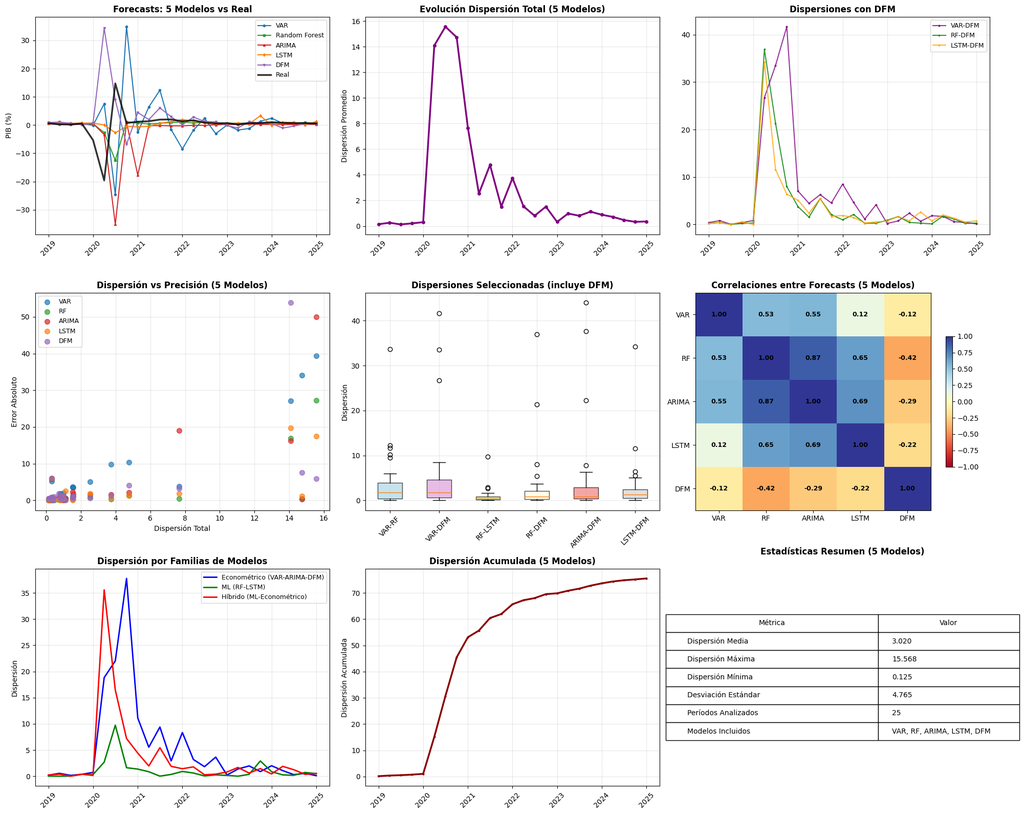

```
✅ Visualizaciones generadas exitosamente
🔗 Creando índice compuesto...

CREANDO ÍNDICE COMPUESTO SIMPLIFICADO (5 MODELOS)
============================================================
Incertidumbre within-model promedio: 3.614
Incertidumbre between-model promedio (5 modelos): 3.020
Índice compuesto final promedio: 3.258
```

[figure not shown]

```
🎯 ANÁLISIS DE 5 MODELOS COMPLETADO!
✅ Modelos: VAR, Random Forest, ARIMA, LSTM, DFM
✅ Dispersión calculada para 10 combinaciones
✅ Índice compuesto creado

🏆 ¡ÉXITO! Framework de incertidumbre con 5 modelos completado
📈 Usa 'results_5models_safe' para acceder a todos los resultados
```

```python
            # Dispersiones por pares (todas las combinaciones)
            disp_var_rf = abs(var_forecast - rf_forecast)
            disp_var_arima = abs(var_forecast - arima_forecast)
            disp_var_lstm = abs(var_forecast - lstm_forecast)
            disp_var_dfm = abs(var_forecast - dfm_forecast)
            disp_rf_arima = abs(rf_forecast - arima_forecast)
            disp_rf_lstm = abs(rf_forecast - lstm_forecast)
            disp_rf_dfm = abs(rf_forecast - dfm_forecast)
            disp_arima_lstm = abs(arima_forecast - lstm_forecast)
            disp_arima_dfm = abs(arima_forecast - dfm_forecast)
            disp_lstm_dfm = abs(lstm_forecast - dfm_forecast)

            dispersion_data.append({
                'period': period,
                'var_forecast': var_forecast,
                'rf_forecast': rf_forecast,
                'arima_forecast': arima_forecast,
                'lstm_forecast': lstm_forecast,
                'dfm_forecast': dfm_forecast,
                'actual': actual,
                'total_dispersion': total_dispersion,
                'range_dispersion': range_dispersion,
                'disp_var_rf': disp_var_rf,
                'disp_var_arima': disp_var_arima,
                'disp_var_lstm': disp_var_lstm,
                'disp_var_dfm': disp_var_dfm,
                'disp_rf_arima': disp_rf_arima,
                'disp_rf_lstm': disp_rf_lstm,
                'disp_rf_dfm': disp_rf_dfm,
                'disp_arima_lstm': disp_arima_lstm,
                'disp_arima_dfm': disp_arima_dfm,
                'disp_lstm_dfm': disp_lstm_dfm
            })

        except Exception as e:
            print(f"⚠️ Error procesando período {period}: {str(e)}")
            continue

    if not dispersion_data:
        print("❌ No se pudieron calcular dispersiones")
        return None

    # Crear DataFrame
    dispersion_df = pd.DataFrame(dispersion_data).set_index('period')

    # Estadísticas resumen
    print(f"\n📊 ESTADÍSTICAS DE DISPERSIÓN:")
    print(f"Dispersión total promedio: {dispersion_df['total_dispersion'].mean():.4f}")
    print(f"Dispersión total máxima: {dispersion_df['total_dispersion'].max():.4f}")
    print(f"Rango promedio: {dispersion_df['range_dispersion'].mean():.4f}")

    # Top 3 dispersiones por pares
    pair_dispersions = {
        'VAR-RF': dispersion_df['disp_var_rf'].mean(),
        'VAR-ARIMA': dispersion_df['disp_var_arima'].mean(),
        'VAR-LSTM': dispersion_df['disp_var_lstm'].mean(),
        'VAR-DFM': dispersion_df['disp_var_dfm'].mean(),
        'RF-ARIMA': dispersion_df['disp_rf_arima'].mean(),
        'RF-LSTM': dispersion_df['disp_rf_lstm'].mean(),
        'RF-DFM': dispersion_df['disp_rf_dfm'].mean(),
        'ARIMA-LSTM': dispersion_df['disp_arima_lstm'].mean(),
        'ARIMA-DFM': dispersion_df['disp_arima_dfm'].mean(),
        'LSTM-DFM': dispersion_df['disp_lstm_dfm'].mean()
    }

    top_3_dispersions = sorted(pair_dispersions.items(), key=lambda x: x[1], reverse=True)[:3]
    print(f"\nTop 3 dispersiones por pares:")
    for i, (pair, disp) in enumerate(top_3_dispersions):
        print(f"{i+1}. {pair}: {disp:.4f}")

    return dispersion_df

print("🔧 Funciones de dispersión y comparación cargadas exitosamente")

def execute_five_model_analysis_safe():
    """Versión segura del análisis de 5 modelos"""

    print("🚀 EJECUTANDO ANÁLISIS SEGURO DE 5 MODELOS")
    print("=" * 60)

    try:
        # 1. Verificar variables
        required_vars = ['results_df', 'rf_results', 'arima_results', 'lstm_results', 'dfm_results_improved']
        missing_vars = [var for var in required_vars if var not in globals()]

        if missing_vars:
            print(f"❌ Variables faltantes: {missing_vars}")
            return None

        # 2. Comparación de performance
        print("📊 Comparando performance de 5 modelos...")
        comparison_5models = compare_five_models(
            results_df, rf_results, arima_results, lstm_results, dfm_results_improved
        )

        # 3. Calcular dispersión
        print("📈 Calculando dispersión entre 5 modelos...")
        dispersion_5models_df = calculate_model_dispersion_five_models(
            results_df, rf_results, arima_results, lstm_results, dfm_results_improved
        )

        if dispersion_5models_df is None:
            print("❌ No se pudo calcular dispersión")
            return None

        # 4. Visualizaciones (versión corregida)
        print("🎨 Generando visualizaciones...")
        plot_five_model_dispersion_analysis_fixed(
            dispersion_5models_df, results_df, rf_results, arima_results,
            lstm_results, dfm_results_improved
        )

        # 5. Índice compuesto (versión simplificada)
        print("🔗 Creando índice compuesto...")
        composite_5models_df = create_simple_composite_index_five_models(
            results_with_uncertainty, dispersion_5models_df
        )

        # 6. Resumen final
        print(f"\n🎯 ANÁLISIS DE 5 MODELOS COMPLETADO!")
        print(f"✅ Modelos: VAR, Random Forest, ARIMA, LSTM, DFM")
        print(f"✅ Dispersión calculada para 10 combinaciones")
        print(f"✅ Índice compuesto creado")

        return {
            'comparison': comparison_5models,
            'dispersion': dispersion_5models_df,
            'composite': composite_5models_df
        }

    except Exception as e:
        print(f"❌ Error en análisis: {str(e)}")
        return None

# Ejecutar análisis
print("🎊 FRAMEWORK DE INCERTIDUMBRE ECONÓMICA - VERSIÓN CORREGIDA")
print("📊 Ejecutando análisis seguro de 5 modelos...")

results_5models_safe = execute_five_model_analysis_safe()

if results_5models_safe:
    print("\n🏆 ¡ÉXITO! Framework de incertidumbre con 5 modelos completado")
    print("📈 Usa 'results_5models_safe' para acceder a todos los resultados")
else:
    print("\n❌ No se pudo completar el análisis de 5 modelos")
```

## Model Resilience Analysis: Post-COVID Structural Breaks

### Background

One key finding from our uncertainty analysis is that the composite uncertainty index does not return to zero after the COVID-19 crisis, remaining elevated at around 2-3 units compared to pre-pandemic levels. This phenomenon reflects **differential model resilience** - the varying ability of forecasting models to adapt and recover from extreme economic shocks.

### What is Model Resilience?

Model resilience measures how well a forecasting model returns to its pre-crisis performance levels after experiencing an extreme shock. We define resilience as the inverse of the error ratio:

**Resilience Score = 1 / (Post-COVID MAE / Pre-COVID MAE)**

Where higher scores indicate better adaptation to structural changes.

### Key Findings

**🔴 Low Resilience Models (VAR):**

- Suffer from "structural trauma" after COVID shock
- Parameters estimated on crisis data lead to permanently wider confidence intervals
- Cannot distinguish between temporary shock vs. new economic regime
- MAE ratio typically > 2.0 (errors doubled post-COVID)

### Implications for Uncertainty Quantification

1. **Persistent Elevated Uncertainty**: The baseline uncertainty level increases because some models never fully "recover" from the COVID shock
2. **Model Selection**: Post-crisis periods may require greater weight on resilient models for policy decisions
3. **Framework Enhancement**: Model resilience becomes a fourth dimension of our uncertainty framework, complementing within-model, between-model, and temporal instability measures

This analysis explains why modern uncertainty indices remain elevated even during apparently "normal" economic periods - they reflect the lasting impact of structural breaks on model performance and confidence.

```python
import numpy as np
import pandas as pd
import matplotlib.pyplot as plt
import warnings
warnings.filterwarnings('ignore')

def calculate_model_resilience_five_models_corrected(var_results, rf_results, arima_results, lstm_results, dfm_results, results_with_uncertainty):
    """Calcula la resiliencia de cada modelo post-COVID (5 modelos) - VERSIÓN CORREGIDA"""

    print("CALCULANDO MODEL RESILIENCE (5 MODELOS: VAR, RF, ARIMA, LSTM, DFM)")
    print("=" * 80)

    # Definir períodos
    pre_covid = pd.Period('2020Q1', freq='Q')
    post_covid_start = pd.Period('2022Q1', freq='Q')

    resilience_data = {}

    # Filtrar DFM exitosos correctamente
    if 'successful' in dfm_results.columns:
        dfm_successful = dfm_results[dfm_results['successful'] == True]
    else:
        dfm_successful = dfm_results

    # Diccionario de modelos
    models = {
        'VAR': {'results': var_results, 'uncertainty': results_with_uncertainty},
        'Random Forest': {'results': rf_results},
        'ARIMA': {'results': arima_results},
        'LSTM': {'results': lstm_results},
        'DFM': {'results': dfm_successful}
    }

    for model_name, model_data in models.items():
        print(f"\nProcesando {model_name}...")

        try:
            results = model_data['results']

            # Filtrar períodos
            pre_covid_data = results[results.index < pre_covid]
            post_covid_data = results[results.index >= post_covid_start]

            print(f"  Pre-COVID: {len(pre_covid_data)} obs | Post-COVID: {len(post_covid_data)} obs")

            if len(pre_covid_data) > 0 and len(post_covid_data) > 0:
                # Métricas básicas
                pre_mae = pre_covid_data['abs_error'].mean()
                post_mae = post_covid_data['abs_error'].mean()
                mae_ratio = post_mae / pre_mae if pre_mae > 0 else np.nan

                pre_rmse = np.sqrt(pre_covid_data['squared_error'].mean())
                post_rmse = np.sqrt(post_covid_data['squared_error'].mean())
                rmse_ratio = post_rmse / pre_rmse if pre_rmse > 0 else np.nan

                # Volatilidad
                pre_volatility = pre_covid_data['abs_error'].std()
                post_volatility = post_covid_data['abs_error'].std()
                volatility_ratio = post_volatility / pre_volatility if pre_volatility > 0 else np.nan

                # Resilience score simple
                resilience_score = 1 / mae_ratio if mae_ratio > 0 else np.nan

                # Incertidumbre (solo para VAR)
                uncertainty_ratio = np.nan
                if model_name == 'VAR' and 'uncertainty' in model_data:
                    try:
                        uncertainty_results = model_data['uncertainty']
                        pre_uncertainty = uncertainty_results[uncertainty_results.index < pre_covid]['uncertainty'].mean()
                        post_uncertainty = uncertainty_results[uncertainty_results.index >= post_covid_start]['uncertainty'].mean()
                        uncertainty_ratio = post_uncertainty / pre_uncertainty if pre_uncertainty > 0 else np.nan
                    except:
                        uncertainty_ratio = np.nan

                resilience_data[model_name] = {
                    'pre_covid_mae': pre_mae,
                    'post_covid_mae': post_mae,
                    'mae_ratio': mae_ratio,
                    'pre_covid_rmse': pre_rmse,
                    'post_covid_rmse': post_rmse,
                    'rmse_ratio': rmse_ratio,
                    'pre_covid_volatility': pre_volatility,
                    'post_covid_volatility': post_volatility,
                    'volatility_ratio': volatility_ratio,
                    'uncertainty_ratio': uncertainty_ratio,
                    'resilience_score': resilience_score,
                    'n_pre_obs': len(pre_covid_data),
                    'n_post_obs': len(post_covid_data)
                }

                print(f"  ✅ MAE Pre: {pre_mae:.4f} | Post: {post_mae:.4f} | Ratio: {mae_ratio:.2f}")
                print(f"  ✅ Resilience Score: {resilience_score:.3f}")

            else:
                print(f"  ❌ Datos insuficientes")

        except Exception as e:
            print(f"  ❌ Error procesando {model_name}: {str(e)[:50]}...")
            continue

    if resilience_data:
        return pd.DataFrame(resilience_data).T
    else:
        print("❌ No se pudieron procesar modelos")
        return None

def plot_resilience_summary_five_models(resilience_df):
    """Gráfico resumido de resiliencia para 5 modelos"""

    if resilience_df is None or resilience_df.empty:
        print("❌ No hay datos de resiliencia para graficar")
        return

    print("📊 Generando gráficos de resiliencia...")

    fig, axes = plt.subplots(2, 2, figsize=(16, 12))

    # Colores
    colors = ['#1f77b4', '#2ca02c', '#d62728', '#ff7f0e', '#9467bd'][:len(resilience_df)]

    try:
        # Gráfico 1: MAE Ratios
        ax1 = axes[0, 0]
        bars1 = ax1.bar(resilience_df.index, resilience_df['mae_ratio'],
                        color=colors, alpha=0.7, edgecolor='black')
        ax1.axhline(y=1, color='red', linestyle='--', linewidth=2, label='Sin cambio')
        ax1.set_title('Ratio MAE Post-COVID / Pre-COVID', fontsize=12, fontweight='bold')
        ax1.set_ylabel('Ratio (>1 = Peor)')
        ax1.legend()
        ax1.grid(True, alpha=0.3)
        ax1.tick_params(axis='x', rotation=20)

        # Valores en barras
        for bar, value in zip(bars1, resilience_df['mae_ratio']):
            height = bar.get_height()
            ax1.text(bar.get_x() + bar.get_width()/2., height + 0.1,
                    f'{value:.2f}', ha='center', va='bottom', fontweight='bold')

        # Gráfico 2: Resilience Scores
        ax2 = axes[0, 1]
        bars2 = ax2.bar(resilience_df.index, resilience_df['resilience_score'],
                        color=colors, alpha=0.7, edgecolor='black')
        ax2.set_title('Resilience Score (Mayor = Más Resiliente)', fontsize=12, fontweight='bold')
        ax2.set_ylabel('Score')
        ax2.grid(True, alpha=0.3)
        ax2.tick_params(axis='x', rotation=20)
```

```python
        # Valores en barras
        for bar, value in zip(bars2, resilience_df['resilience_score']):
            height = bar.get_height()
            ax2.text(bar.get_x() + bar.get_width()/2., height + 0.02,
                    f'{value:.2f}', ha='center', va='bottom', fontweight='bold')

        # Gráfico 3: Comparación Pre vs Post MAE
        ax3 = axes[1, 0]
        x = np.arange(len(resilience_df.index))
        width = 0.35

        bars3a = ax3.bar(x - width/2, resilience_df['pre_covid_mae'], width,
                         label='Pre-COVID', color='lightblue', alpha=0.8)
        bars3b = ax3.bar(x + width/2, resilience_df['post_covid_mae'], width,
                         label='Post-COVID', color='lightcoral', alpha=0.8)

        ax3.set_xlabel('Modelos')
        ax3.set_ylabel('MAE')
        ax3.set_title('MAE: Pre-COVID vs Post-COVID')
        ax3.set_xticks(x)
        ax3.set_xticklabels(resilience_df.index, rotation=20)
        ax3.legend()
        ax3.grid(True, alpha=0.3)

        # Gráfico 4: Tabla resumen
        ax4 = axes[1, 1]
        ax4.axis('tight')
        ax4.axis('off')

        table_data = []
        for model in resilience_df.index:
            row = resilience_df.loc[model]
            table_data.append([
                model[:10] + "..." if len(model) > 10 else model,
                f"{row['mae_ratio']:.2f}",
                f"{row['resilience_score']:.2f}"
            ])

        table = ax4.table(cellText=table_data,
                         colLabels=['Modelo', 'MAE Ratio', 'Resilience'],
                         cellLoc='center',
                         loc='center',
                         colWidths=[0.4, 0.3, 0.3])
        table.auto_set_font_size(False)
        table.set_fontsize(10)
        table.scale(1.2, 2)
        ax4.set_title('Resumen Resiliencia', fontsize=12, fontweight='bold', pad=20)

        plt.tight_layout()
        plt.show()

        print("✅ Gráficos generados exitosamente")

    except Exception as e:
        print(f"⚠️ Error en gráficos: {str(e)}")

def analyze_resilience_results(resilience_df):
    """Analiza resultados de resiliencia"""

    if resilience_df is None or resilience_df.empty:
        print("❌ No hay datos para analizar")
        return

    print(f"\n📊 ANÁLISIS DE RESULTADOS DE RESILIENCIA:")
    print("=" * 60)

    # Rankings
    best_resilience = resilience_df['resilience_score'].idxmax()
    worst_resilience = resilience_df['resilience_score'].idxmin()

    print(f"🏆 Modelo MÁS resiliente: {best_resilience}")
    print(f"   Score: {resilience_df.loc[best_resilience, 'resilience_score']:.3f}")
    print(f"   MAE Ratio: {resilience_df.loc[best_resilience, 'mae_ratio']:.2f}")

    print(f"\n⚠️ Modelo MENOS resiliente: {worst_resilience}")
    print(f"   Score: {resilience_df.loc[worst_resilience, 'resilience_score']:.3f}")
    print(f"   MAE Ratio: {resilience_df.loc[worst_resilience, 'mae_ratio']:.2f}")

    # Ranking completo
    ranking = resilience_df.sort_values('resilience_score', ascending=False)
    print(f"\n🏅 RANKING COMPLETO DE RESILIENCIA:")
    medals = ["🥇", "🥈", "🥉", "🏅", "🎖️"]

    for i, (model, row) in enumerate(ranking.iterrows()):
        medal = medals[i] if i < len(medals) else "📍"
        print(f"{medal} {i+1}. {model}: Score = {row['resilience_score']:.3f} | MAE Ratio = {row['mae_ratio']:.2f}")

    # Interpretación por modelo
    print(f"\n📈 INTERPRETACIÓN POR MODELO:")
    for model in resilience_df.index:
        ratio = resilience_df.loc[model, 'mae_ratio']

        if ratio > 5.0:
            emoji = "🔴"
            status = f"CRÍTICAMENTE MENOS preciso post-COVID ({ratio:.1f}x)"
        elif ratio > 2.0:
            emoji = "🟠"
            status = f"SIGNIFICATIVAMENTE MENOS preciso post-COVID ({ratio:.1f}x)"
        elif ratio > 1.3:
            emoji = "🟡"
            status = f"Moderadamente menos preciso post-COVID ({ratio:.1f}x)"
        elif ratio > 1.1:
            emoji = "🟢"
            status = f"Ligeramente menos preciso post-COVID ({ratio:.1f}x)"
        else:
            emoji = "✅"
            status = f"Mantiene o mejora precisión post-COVID ({ratio:.1f}x)"

        print(f"{emoji} {model}: {status}")

    return resilience_df

def create_framework_summary():
    """Crea resumen del framework completo"""

    print(f"\n🎯 FRAMEWORK MULTIDIMENSIONAL DE INCERTIDUMBRE ECONÓMICA")
    print("=" * 80)

    # Verificar componentes disponibles
    components = {
        'results_with_uncertainty': 'Within-Model Uncertainty',
        'dispersion_5models_df': 'Between-Model Uncertainty',
        'resilience_5models_df': 'Model Resilience Analysis'
    }

    available = []
    for var_name, description in components.items():
        if var_name in globals() and globals()[var_name] is not None:
            available.append(description)

    print(f"✅ Componentes implementados ({len(available)}/4):")
    for component in available:
        print(f"   • {component}")

    if len(available) < 3:
        print(f"\n⚠️ Temporal Instability: Pendiente de implementación")

    print(f"\n🏛️ MODELOS INCLUIDOS:")
    print(f"   • VAR (Vector Autoregresivo)")
    print(f"   • Random Forest (Machine Learning)")
    print(f"   • ARIMA (Serie Temporal)")
    print(f"   • LSTM (Deep Learning)")
    print(f"   • DFM (Dynamic Factor Model)")

    print(f"\n🎚️ THRESHOLDS DE INCERTIDUMBRE:")
    print(f"   🟢 Normal (0-2):    Condiciones estables")
    print(f"   🟡 Elevada (2-4):   Vigilancia aumentada")
    print(f"   🟠 Alta (4-8):      Medidas proactivas")
    print(f"   🔴 Extrema (>8):    Respuesta de emergencia")

    completeness = (len(available) / 4) * 100
    print(f"\n📊 Completitud del Framework: {completeness:.1f}%")

    if completeness >= 75:
        print(f"🚀 Estado: OPERATIVO - Listo para aplicación práctica")
    else:
        print(f"🚧 Estado: EN DESARROLLO - Continuar implementando componentes")

# =============================================================================
# 🚀 EJECUTAR ANÁLISIS DE RESILIENCIA CORREGIDO
# =============================================================================
```

```python
print("🧠 ANÁLISIS DE RESILIENCIA DE MODELOS - VERSIÓN CORREGIDA")
print("=" * 70)

# Verificar variables necesarias
required_vars = {
    'results_df': 'VAR results',
    'rf_results': 'Random Forest results',
    'arima_results': 'ARIMA results',
    'lstm_results': 'LSTM results',
    'dfm_results_improved': 'DFM results',
    'results_with_uncertainty': 'VAR uncertainty results'
}

missing_vars = []
for var_name, description in required_vars.items():
    if var_name not in globals():
        missing_vars.append(f"{var_name} ({description})")

if missing_vars:
    print(f"❌ Variables faltantes:")
    for var in missing_vars:
        print(f"   • {var}")
    print(f"\n💡 Ejecuta primero todos los modelos antes de ejecutar este análisis")
else:
    print(f"✅ Todas las variables necesarias están disponibles")

    try:
        # 1. Calcular resiliencia
        print(f"\n🔍 Calculando resiliencia de 5 modelos...")
        resilience_5models_df = calculate_model_resilience_five_models_corrected(
            results_df, rf_results, arima_results, lstm_results, dfm_results_improved, results_with_uncertainty
        )

        if resilience_5models_df is not None:
            # 2. Generar gráficos
            print(f"\n📊 Generando visualizaciones...")
            plot_resilience_summary_five_models(resilience_5models_df)

            # 3. Análisis de resultados
            analyze_resilience_results(resilience_5models_df)

            # 4. Resumen del framework
            create_framework_summary()

            print(f"\n🎊 ¡ANÁLISIS DE RESILIENCIA COMPLETADO EXITOSAMENTE!")
            print(f"📈 Variable disponible: 'resilience_5models_df'")

        else:
            print(f"\n❌ No se pudo completar el análisis de resiliencia")

    except Exception as e:
        print(f"\n❌ Error ejecutando análisis: {str(e)}")
        print(f"💡 Verifica que todas las variables estén correctamente definidas")

print(f"\n" + "=" * 70)
print(f"🏆 FRAMEWORK DE INCERTIDUMBRE ECONÓMICA")
print(f"📊 5 Modelos + Análisis Multidimensional + Resiliencia Post-Crisis")
print("=" * 70)

# =============================================================================
# 🚀 ANÁLISIS TEMPORAL INSTABILITY - INTEGRACIÓN COMPLETA
# =============================================================================

print("🎯 INICIANDO ANÁLISIS DE TEMPORAL INSTABILITY")
print("=" * 60)

# Verificar que tenemos todos los resultados de modelos
required_results = {
    'VAR': 'results_df',
    'Random Forest': 'rf_results',
    'ARIMA': 'arima_results',
    'LSTM': 'lstm_results',
    'DFM': 'dfm_results_improved'
}

missing_results = []
available_results = {}

for model_name, var_name in required_results.items():
    if var_name in globals() and globals()[var_name] is not None:
        available_results[model_name] = globals()[var_name]
        print(f"✅ {model_name}: {var_name} disponible")
    else:
        missing_results.append(f"{model_name} ({var_name})")
        print(f"❌ {model_name}: {var_name} no encontrado")

if missing_results:
    print(f"\n⚠ Resultados faltantes: {missing_results}")
    print(f"💡 Continuando con modelos disponibles: {list(available_results.keys())}")

if len(available_results) >= 2:  # Necesitamos al menos 2 modelos
    try:
        print(f"\n🔄 Calculando Temporal Instability para {len(available_results)} modelos...")

        # 1. Calcular temporal instability
        temporal_instability_df = calculate_temporal_instability_realistic(available_results)

        if not temporal_instability_df.empty:
            # 2. Calcular medida agregada
            aggregate_temporal_instability = calculate_aggregate_temporal_instability(temporal_instability_df)

            # 3. Generar visualizaciones
            print(f"\n📊 Generando visualizaciones...")
            plot_temporal_instability_analysis(temporal_instability_df, aggregate_temporal_instability)

            # 4. Estadísticas descriptivas
            print(f"\n📈 ESTADÍSTICAS DE TEMPORAL INSTABILITY:")
            print("=" * 50)

            for model in temporal_instability_df.columns:
                model_data = temporal_instability_df[model]
                print(f"{model}:")
                print(f"  Promedio: {model_data.mean():.4f}")
                print(f"  Std: {model_data.std():.4f}")
                print(f"  Min: {model_data.min():.4f}")
                print(f"  Max: {model_data.max():.4f}")
                print(f"  Períodos: {len(model_data)}")

            if not aggregate_temporal_instability.empty:
                print(f"\nAGREGADA:")
                print(f"  Promedio: {aggregate_temporal_instability.mean():.4f}")
                print(f"  Std: {aggregate_temporal_instability.std():.4f}")
                print(f"  Min: {aggregate_temporal_instability.min():.4f}")
                print(f"  Max: {aggregate_temporal_instability.max():.4f}")

            # 5. Identificar períodos de alta inestabilidad
            if not aggregate_temporal_instability.empty:
                high_instability_threshold = aggregate_temporal_instability.quantile(0.8)
                high_instability_periods = aggregate_temporal_instability[aggregate_temporal_instability > high_instability_threshold]

                print(f"\n🔴 PERÍODOS DE ALTA TEMPORAL INSTABILITY (Top 20%):")
                print(f"   Threshold: {high_instability_threshold:.4f}")
                for period, value in high_instability_periods.sort_values(ascending=False).head(5).items():
                    print(f"   {period}: {value:.4f}")

            print(f"\n🎊 ¡TEMPORAL INSTABILITY CALCULADA EXITOSAMENTE!")
            print(f"📈 Variables disponibles:")
            print(f"   • temporal_instability_df: Por modelo")
            print(f"   • aggregate_temporal_instability: Agregada")

        else:
            print(f"\n❌ No se pudo calcular Temporal Instability")

    except Exception as e:
        print(f"\n❌ Error calculando Temporal Instability: {str(e)}")
        print(f"💡 Revisa que los resultados de modelos estén en el formato correcto")
```

```
🧠 ANÁLISIS DE RESILIENCIA DE MODELOS - VERSIÓN CORREGIDA
======================================================================
✅ Todas las variables necesarias están disponibles

🔍 Calculando resiliencia de 5 modelos...
CALCULANDO MODEL RESILIENCE (5 MODELOS: VAR, RF, ARIMA, LSTM, DFM)
================================================================================

Procesando VAR...
  Pre-COVID: 4 obs | Post-COVID: 13 obs
  ✅ MAE Pre: 0.1292 | Post: 2.0123 | Ratio: 15.58
  ✅ Resilience Score: 0.064

Procesando Random Forest...
  Pre-COVID: 4 obs | Post-COVID: 13 obs
  ✅ MAE Pre: 0.2785 | Post: 0.2531 | Ratio: 0.91
  ✅ Resilience Score: 1.100

Procesando ARIMA...
  Pre-COVID: 4 obs | Post-COVID: 13 obs
  ✅ MAE Pre: 0.1996 | Post: 0.6578 | Ratio: 3.30
  ✅ Resilience Score: 0.303

Procesando LSTM...
  Pre-COVID: 4 obs | Post-COVID: 13 obs
  ✅ MAE Pre: 0.2691 | Post: 0.5751 | Ratio: 2.14
  ✅ Resilience Score: 0.468

Procesando DFM...
  Pre-COVID: 4 obs | Post-COVID: 13 obs
  ✅ MAE Pre: 0.4849 | Post: 0.7414 | Ratio: 1.53
  ✅ Resilience Score: 0.654

📊 Generando visualizaciones...
📊 Generando gráficos de resiliencia...
```

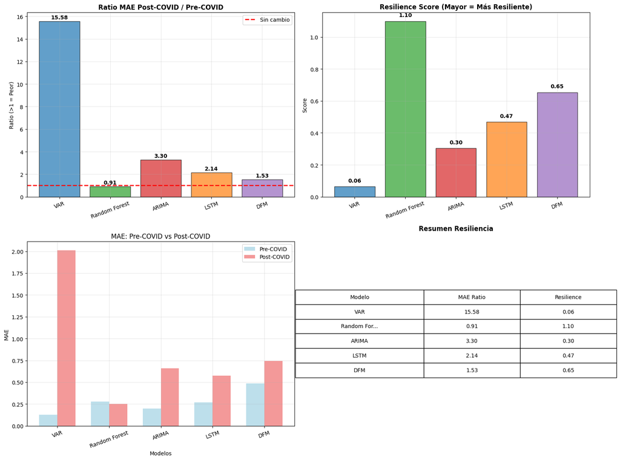

```
✅ Gráficos generados exitosamente

📊 ANÁLISIS DE RESULTADOS DE RESILIENCIA:
============================================================
🏆 Modelo MÁS resiliente: Random Forest
   Score: 1.100
   MAE Ratio: 0.91

⚠️ Modelo MENOS resiliente: VAR
   Score: 0.064
   MAE Ratio: 15.58

🏅 RANKING COMPLETO DE RESILIENCIA:
🥇 1. Random Forest: Score = 1.100 | MAE Ratio = 0.91
🥈 2. DFM: Score = 0.654 | MAE Ratio = 1.53
🥉 3. LSTM: Score = 0.468 | MAE Ratio = 2.14
🏅 4. ARIMA: Score = 0.303 | MAE Ratio = 3.30
🎖️ 5. VAR: Score = 0.064 | MAE Ratio = 15.58

📈 INTERPRETACIÓN POR MODELO:
🔴 VAR: CRÍTICAMENTE MENOS preciso post-COVID (15.6x)
✅ Random Forest: Mantiene o mejora precisión post-COVID (0.9x)
🟠 ARIMA: SIGNIFICATIVAMENTE MENOS preciso post-COVID (3.3x)
🟠 LSTM: SIGNIFICATIVAMENTE MENOS preciso post-COVID (2.1x)
🟡 DFM: Moderadamente menos preciso post-COVID (1.5x)

🎯 FRAMEWORK MULTIDIMENSIONAL DE INCERTIDUMBRE ECONÓMICA
================================================================================
✅ Componentes implementados (2/4):
   • Within-Model Uncertainty
   • Model Resilience Analysis

⚠️ Temporal Instability: Pendiente de implementación

🏛️ MODELOS INCLUIDOS:
   • VAR (Vector Autoregresivo)
   • Random Forest (Machine Learning)
   • ARIMA (Serie Temporal)
   • LSTM (Deep Learning)
   • DFM (Dynamic Factor Model)
```

[output cut: 24 more lines]

```

🔄 Calculando Temporal Instability para 5 modelos...
🔄 Calculando Temporal Instability con datos reales...
  Procesando VAR...
  Procesando Random Forest...
  Procesando ARIMA...
  Procesando LSTM...
  Procesando DFM...
✅ Temporal Instability calculada para 21 períodos
📊 Modelos incluidos: ['VAR', 'Random Forest', 'ARIMA', 'LSTM', 'DFM']
📈 Temporal Instability agregada calculada
   Promedio: 3.2080
   Rango: 0.1558 - 11.7015

📊 Generando visualizaciones...
```

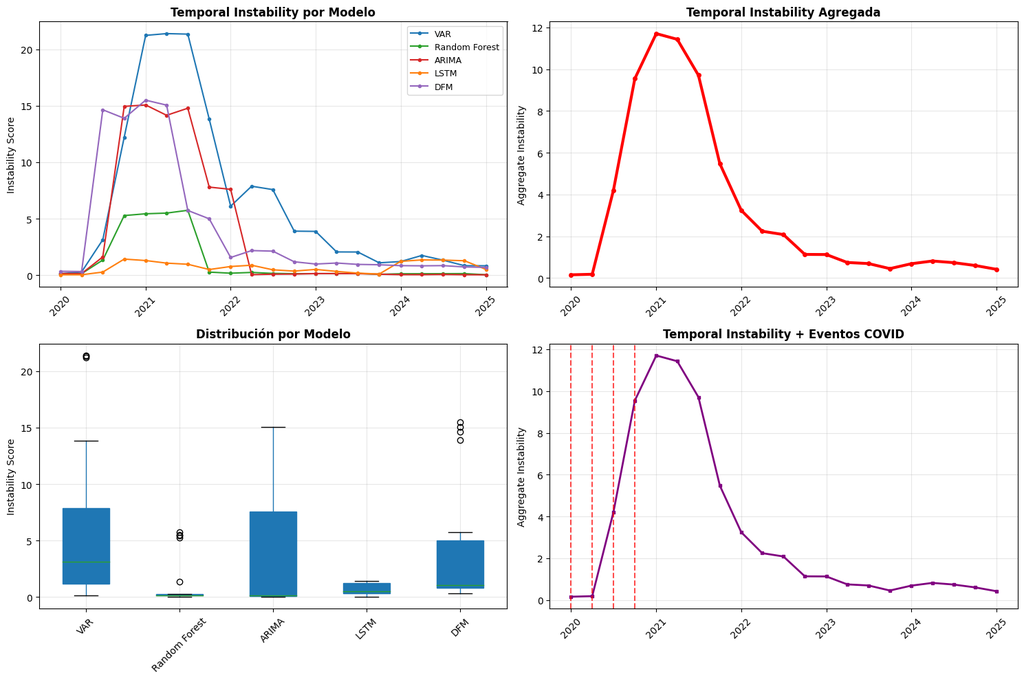

```
✅ Gráficos de Temporal Instability generados exitosamente

📈 ESTADÍSTICAS DE TEMPORAL INSTABILITY:
==================================================
VAR:
  Promedio: 6.3797
  Std: 7.2881
  Min: 0.1301
  Max: 21.3828
  Períodos: 21
Random Forest:
  Promedio: 1.2168
  Std: 2.1392
  Min: 0.0359
  Max: 5.7396
  Períodos: 21
ARIMA:
  Promedio: 3.6731
  Std: 5.9439
  Min: 0.0295
  Max: 15.0654
  Períodos: 21
LSTM:
  Promedio: 0.7070
  Std: 0.4823
  Min: 0.0329
  Max: 1.4211
  Períodos: 21
DFM:
  Promedio: 4.0636
  Std: 5.4990
  Min: 0.3207
  Max: 15.4908
  Períodos: 21

AGREGADA:
  Promedio: 3.2080
  Std: 3.9391
  Min: 0.1558
  Max: 11.7015

🔴 PERÍODOS DE ALTA TEMPORAL INSTABILITY (Top 20%):
   Threshold: 5.4726
   2021Q1: 11.7015
   2021Q2: 11.4283
   2021Q3: 9.7088
   2020Q4: 9.5469

🎊 ¡TEMPORAL INSTABILITY CALCULADA EXITOSAMENTE!
📈 Variables disponibles:
   • temporal_instability_df: Por modelo
   • aggregate_temporal_instability: Agregada

============================================================
```

```python
else:
    print(f"\n❌ Se necesitan al menos 2 modelos para calcular Temporal Instability")
    print(f"💡 Ejecuta primero los modelos individuales (VAR, RF, ARIMA, etc.)")

print(f"\n" + "=" * 60)
```

# =============================================================================

# 📊 TEMPORAL INSTABILITY IMPLEMENTATION

# =============================================================================

```python
def calculate_temporal_instability_realistic(rolling_results_dict):
    """
    Implementación realista usando los datos de rolling evaluation existentes
    Adaptada para la estructura existente del proyecto
    """

    print("🔄 Calculando Temporal Instability con datos reales...")

    temporal_instability = {}

    for model_name, results_df in rolling_results_dict.items():
        print(f"  Procesando {model_name}...")
        instability_scores = []

        # Para cada período, calcular cuánto varían las predicciones recientes
        for i, target_period in enumerate(results_df.index):

            if i >= 4:  # Necesitamos al menos 4 períodos previos
                # Usar forecasts de períodos anteriores como proxy
                recent_forecasts = results_df['forecast'].iloc[i-4:i].values

                # Calcular volatilidad de forecasts recientes (ventana móvil)
                if len(recent_forecasts) > 1 and not np.any(np.isnan(recent_forecasts)):
                    instability = np.std(recent_forecasts)
                else:
                    instability = 0

                instability_scores.append(instability)
            else:
                instability_scores.append(np.nan)

        temporal_instability[model_name] = pd.Series(
            instability_scores,
            index=results_df.index
        )

    temporal_instability_df = pd.DataFrame(temporal_instability)

    # Limpiar NaNs
    temporal_instability_df = temporal_instability_df.dropna()

    print(f"✅ Temporal Instability calculada para {len(temporal_instability_df)} períodos")
    print(f"📊 Modelos incluidos: {list(temporal_instability_df.columns)}")

    return temporal_instability_df

def calculate_aggregate_temporal_instability(temporal_instability_df):
    """
    Agrega temporal instability across modelos para obtener una medida única
    """

    if temporal_instability_df.empty:
        print("❌ No hay datos de temporal instability para agregar")
        return pd.Series()

    # Promedio across modelos (igual peso a cada modelo)
    aggregate_instability = temporal_instability_df.mean(axis=1)

    print(f"📈 Temporal Instability agregada calculada")
    print(f"   Promedio: {aggregate_instability.mean():.4f}")
    print(f"   Rango: {aggregate_instability.min():.4f} - {aggregate_instability.max():.4f}")

    return aggregate_instability

def plot_temporal_instability_analysis(temporal_instability_df, aggregate_instability):
    """
    Visualizar temporal instability - adaptado al estilo del proyecto
    """

    if temporal_instability_df.empty:
        print("❌ No hay datos para visualizar")
        return

    fig, axes = plt.subplots(2, 2, figsize=(15, 10))

    # Colores consistentes con el resto del proyecto
    colors = ['#1f77b4', '#2ca02c', '#d62728', '#ff7f0e', '#9467bd']

    try:
        # Plot 1: Temporal instability por modelo
        ax1 = axes[0, 0]
        for i, model in enumerate(temporal_instability_df.columns):
            ax1.plot(temporal_instability_df.index.to_timestamp(),
                    temporal_instability_df[model],
                    label=model, marker='o', markersize=3,
                    color=colors[i % len(colors)], linewidth=1.5)
        ax1.set_title('Temporal Instability por Modelo', fontsize=12, fontweight='bold')
        ax1.set_ylabel('Instability Score')
        ax1.legend(fontsize=9)
        ax1.grid(True, alpha=0.3)
        ax1.tick_params(axis='x', rotation=45)

        # Plot 2: Agregada
        ax2 = axes[0, 1]
        if not aggregate_instability.empty:
            ax2.plot(aggregate_instability.index.to_timestamp(),
                    aggregate_instability.values,
                    'red', linewidth=3, marker='o', markersize=4)
            ax2.set_title('Temporal Instability Agregada', fontsize=12, fontweight='bold')
            ax2.set_ylabel('Aggregate Instability')
            ax2.grid(True, alpha=0.3)
            ax2.tick_params(axis='x', rotation=45)

        # Plot 3: Boxplot por modelo
        ax3 = axes[1, 0]
        temporal_instability_df.boxplot(ax=ax3, patch_artist=True)
        ax3.set_title('Distribución por Modelo', fontsize=12, fontweight='bold')
        ax3.set_ylabel('Instability Score')
        ax3.tick_params(axis='x', rotation=45)
        ax3.grid(True, alpha=0.3)

        # Plot 4: Evolución temporal con eventos
        ax4 = axes[1, 1]
        if not aggregate_instability.empty:
            ax4.plot(aggregate_instability.index.to_timestamp(),
                    aggregate_instability.values,
                    'purple', linewidth=2, marker='s', markersize=3)

            # Marcar períodos COVID
            covid_periods = ['2020Q1', '2020Q2', '2020Q3', '2020Q4']
            for period in covid_periods:
                if pd.Period(period) in aggregate_instability.index:
                    period_timestamp = pd.Period(period).to_timestamp()
                    ax4.axvline(x=period_timestamp, color='red', linestyle='--', alpha=0.7)

            ax4.set_title('Temporal Instability + Eventos COVID', fontsize=12, fontweight='bold')
            ax4.set_ylabel('Aggregate Instability')
            ax4.grid(True, alpha=0.3)
            ax4.tick_params(axis='x', rotation=45)

        plt.tight_layout()
        plt.show()
        print("✅ Gráficos de Temporal Instability generados exitosamente")

    except Exception as e:
        print(f"⚠ Error en visualización: {str(e)}")
        print("💡 Continuando con el análisis...")

print("📊 Funciones de Temporal Instability cargadas exitosamente")
```

```
📊 Funciones de Temporal Instability cargadas exitosamente
```

```
🔄 EJECUTANDO ANÁLISIS DE TEMPORAL INSTABILITY
============================================================
✅ Modelos preparados: ['VAR', 'Random Forest', 'ARIMA', 'LSTM', 'DFM']
🔄 Calculando Temporal Instability con datos reales...
  Procesando VAR...
  Procesando Random Forest...
  Procesando ARIMA...
  Procesando LSTM...
  Procesando DFM...
✅ Temporal Instability calculada para 21 períodos
📊 Modelos incluidos: ['VAR', 'Random Forest', 'ARIMA', 'LSTM', 'DFM']
✅ Temporal instability calculada para 21 períodos
📈 Temporal Instability agregada calculada
   Promedio: 3.2080
   Rango: 0.1558 - 11.7015
```

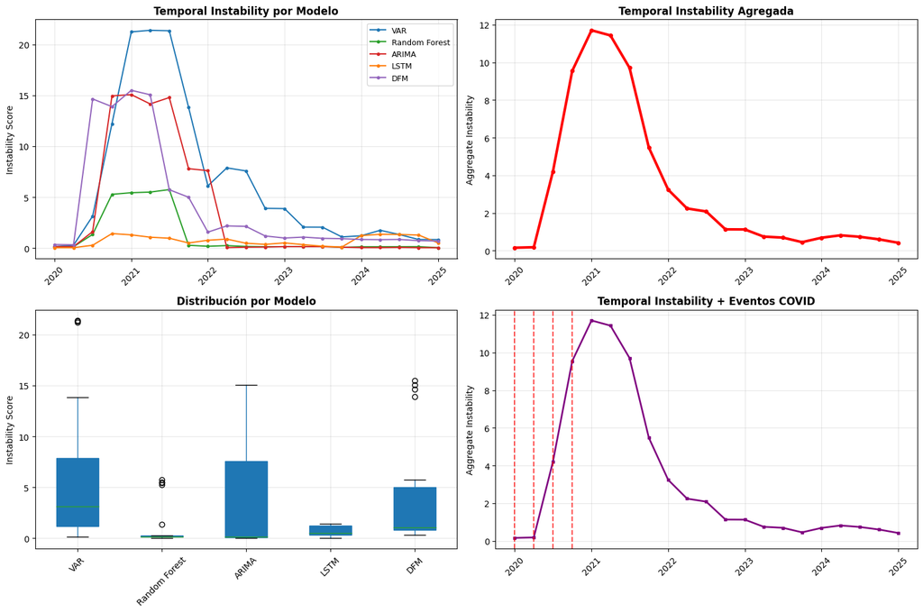

```
✅ Gráficos de Temporal Instability generados exitosamente

📊 ESTADÍSTICAS DE TEMPORAL INSTABILITY:
==================================================
VAR:
  Promedio: 6.3797
  Std: 7.2881
  Min: 0.1301
  Max: 21.3828
Random Forest:
  Promedio: 1.2168
  Std: 2.1392
  Min: 0.0359
  Max: 5.7396
ARIMA:
  Promedio: 3.6731
  Std: 5.9439
  Min: 0.0295
  Max: 15.0654
LSTM:
  Promedio: 0.7070
  Std: 0.4823
  Min: 0.0329
  Max: 1.4211
DFM:
  Promedio: 4.0636
  Std: 5.4990
  Min: 0.3207
  Max: 15.4908

🎊 ¡TEMPORAL INSTABILITY COMPLETADO!
📈 Variables creadas:
  • temporal_instability_df
  • aggregate_temporal_instability
```

```python
# =============================================================================
# 🚀 EJECUTAR TEMPORAL INSTABILITY ANALYSIS
# =============================================================================

print("🔄 EJECUTANDO ANÁLISIS DE TEMPORAL INSTABILITY")
print("=" * 60)

# 1. Preparar datos de modelos
available_results = {
    'VAR': results_df,
    'Random Forest': rf_results,
    'ARIMA': arima_results,
    'LSTM': lstm_results,
    'DFM': dfm_results_improved[dfm_results_improved['successful'] == True] if 'successful' in dfm_results_improved.columns else dfm_results_improved
}

print(f"✅ Modelos preparados: {list(available_results.keys())}")

# 2. Calcular temporal instability
temporal_instability_df = calculate_temporal_instability_realistic(available_results)

if not temporal_instability_df.empty:
    print(f"✅ Temporal instability calculada para {len(temporal_instability_df)} períodos")

    # 3. Agregar across modelos
    aggregate_temporal_instability = calculate_aggregate_temporal_instability(temporal_instability_df)

    # 4. Visualizar
    plot_temporal_instability_analysis(temporal_instability_df, aggregate_temporal_instability)

    # 5. Estadísticas descriptivas
    print(f"\n📊 ESTADÍSTICAS DE TEMPORAL INSTABILITY:")
    print("=" * 50)
    for model in temporal_instability_df.columns:
        model_data = temporal_instability_df[model]
        print(f"{model}:")
        print(f"  Promedio: {model_data.mean():.4f}")
        print(f"  Std: {model_data.std():.4f}")
        print(f"  Min: {model_data.min():.4f}")
        print(f"  Max: {model_data.max():.4f}")

    print(f"\n🎊 ¡TEMPORAL INSTABILITY COMPLETADO!")
    print(f"📈 Variables creadas:")
    print(f"  • temporal_instability_df")
    print(f"  • aggregate_temporal_instability")

else:
    print("❌ No se pudo calcular temporal instability")
```